# Maryland Per Capita Personal Income Analysis

## Executive Summary

**Data Source:** Maryland State Database  
**Database:** Maryland  
**Table:** PerCapitaPersonalIncome  
**Note:** All income values are in U.S. dollars.

```python
import os
import pandas as pd
import numpy as np
import seaborn as sns
import matplotlib.pyplot as plt
import dotenv
import mssql_python
import warnings

warnings.filterwarnings("ignore", message="pandas only supports SQLAlchemy connectable")

# Set plotting style
sns.set_palette("husl")
plt.rcParams['figure.dpi'] = 100

# Helper function to format large numbers
def format_currency(value):
    """Format currency values for better readability"""
    if pd.isna(value):
        return "N/A"
    if value >= 1_000_000_000:
        return f"${value/1_000_000_000:.2f}B"
    elif value >= 1_000_000:
        return f"${value/1_000_000:.2f}M"
    elif value >= 1_000:
        return f"${value/1_000:.2f}K"
    else:
        return f"${value:.2f}"

# Load environment variables
dotenv.load_dotenv()
SQL_CONNECTION_STRING = os.getenv("SQL_CONNECTION_STRING")

if not SQL_CONNECTION_STRING:
    raise ValueError("SQL_CONNECTION_STRING not found in environment variables. Please add it to your .env file.")

print("✓ All imports and configuration loaded")
print("✓ Database connection string found")
print("="*80)
```

```
✓ All imports and configuration loaded
✓ Database connection string found
================================================================================
```

## 1. Data Loading & Initial Exploration

Loading Per Capita Personal Income data from SQL Server database and performing initial data inspection.

```python
# Connect and load data from SQL
SQL_QUERY = """
SELECT *
FROM [Maryland].[dbo].[PerCapitaPersonalIncome]
"""

print("📊 Loading Maryland Per Capita Personal Income Data...\n")

try:
    conn = mssql_python.connect(SQL_CONNECTION_STRING)
    df = pd.read_sql(SQL_QUERY, conn)
    conn.close()

    print(f"✓ Data loaded successfully: {len(df):,} rows × {len(df.columns)} columns")
    print(f"✓ Columns: {', '.join(df.columns.tolist())}")

except Exception as e:
    print(f"✗ Error loading data: {e}")
    raise

print("\n" + "="*80)
```

```
📊 Loading Maryland Per Capita Personal Income Data...

✓ Data loaded successfully: 11 rows × 26 columns
✓ Columns: Year, Maryland, Allegany, AnneArundel, BaltimoreCity, Baltimore, Calvert, Caroline, Carroll, Cecil, Charles, Dorchester, Frederick, Garrett, Harford, Howard, Kent, Montgomery, PrinceGeorges, QueenAnnes, Somerset, StMarys, Talbot, Washington, Wicomico, Worcester

================================================================================
```

```python
# Display first few rows
print("First 10 rows of the dataset:\n")
print(df.head(10))

print("\n" + "="*80)
print("\nLast 10 rows of the dataset:\n")
print(df.tail(10))

print("\n" + "="*80)
```

```
First 10 rows of the dataset:

   Year  Maryland  Allegany  AnneArundel  BaltimoreCity  Baltimore  Calvert  \
0  2013   51880.0   33017.0      56776.0        39910.0    50262.0  52699.0
1  2014   53084.0   34736.0      58365.0        41963.0    51577.0  54038.0
2  2015   55041.0   35730.0      60207.0        43898.0    53029.0  56469.0
3  2016   56614.0   37532.0      61667.0        45271.0    53894.0  57748.0
4  2017   58251.0   38590.0      63346.0        46787.0    55677.0  59271.0
5  2018   59919.0   40117.0      65309.0        49059.0    57505.0  60978.0
6  2019   61725.0   41527.0      67527.0        49861.0    60605.0  63356.0
7  2020   64884.0   45223.0      72136.0        53960.0    63856.0  66855.0
8  2021   69081.0   47462.0      77764.0        58764.0    67143.0  68843.0
9  2022   71340.0   46913.0      79335.0        60799.0    70461.0  71427.0

   Caroline  Carroll    Cecil  ...     Kent  Montgomery  PrinceGeorges  \
```

[output cut: 149 more lines]

## 2. Data Structure & Quality Assessment

Understanding the dataset's structure, data types, and identifying any data quality issues.

```python
# Data Info
print("Dataset Information:\n")
print(df.info())

print("\n" + "="*80)
print("\nData Types Summary:\n")
dtype_counts = df.dtypes.value_counts()
for dtype, count in dtype_counts.items():
    print(f"  {dtype}: {count} columns")

print("\n" + "="*80)
print("\nDataset Shape:")
print(f"  Rows: {df.shape[0]:,}")
print(f"  Columns: {df.shape[1]}")
print(f"  Total Cells: {df.shape[0] * df.shape[1]:,}")

print("\n" + "="*80)
```

```
Dataset Information:

<class 'pandas.core.frame.DataFrame'>
RangeIndex: 11 entries, 0 to 10
Data columns (total 26 columns):
 #   Column         Non-Null Count  Dtype
---  ------         --------------  -----
 0   Year           11 non-null     int64
 1   Maryland       11 non-null     float64
 2   Allegany       11 non-null     float64
 3   AnneArundel    11 non-null     float64
 4   BaltimoreCity  11 non-null     float64
 5   Baltimore      11 non-null     float64
 6   Calvert        11 non-null     float64
 7   Caroline       11 non-null     float64
 8   Carroll        11 non-null     float64
 9   Cecil          11 non-null     float64
 10  Charles        11 non-null     float64
 11  Dorchester     11 non-null     float64
 12  Frederick      11 non-null     float64
 13  Garrett        11 non-null     float64
 14  Harford        11 non-null     float64
 15  Howard         11 non-null     float64
 16  Kent           11 non-null     float64
 17  Montgomery     11 non-null     float64
 18  PrinceGeorges  11 non-null     float64
 19  QueenAnnes     11 non-null     float64
 20  Somerset       11 non-null     float64
 21  StMarys        11 non-null     float64
 22  Talbot         11 non-null     float64
 23  Washington     11 non-null     float64
 24  Wicomico       11 non-null     float64
 25  Worcester      11 non-null     float64
dtypes: float64(25), int64(1)
memory usage: 2.4 KB
None

================================================================================

Data Types Summary:

  float64: 25 columns
  int64: 1 columns

================================================================================

Dataset Shape:
  Rows: 11
  Columns: 26
  Total Cells: 286

================================================================================
```

```python
# Missing Values Analysis
print("Missing Values Analysis:\n")

missing_counts = df.isnull().sum()
missing_pct = (df.isnull().sum() / len(df)) * 100

missing_df = pd.DataFrame({
    'Column': df.columns,
    'Missing Count': missing_counts.values,
    'Missing %': missing_pct.values
}).sort_values('Missing Count', ascending=False)

print(missing_df.to_string(index=False))

print("\n" + "="*80)
print("\nMissing Data Summary:")
print(f"  Total columns with missing data: {(missing_counts > 0).sum()}")
print(f"  Total missing values: {missing_counts.sum():,}")
print(f"  Overall missing percentage: {(missing_counts.sum() / (df.shape[0] * df.shape[1]) * 100):.2f}%")

# Visualize missing data if any exists
if missing_counts.sum() > 0:
    fig, ax = plt.subplots(figsize=(12, 6))
    missing_data = missing_df[missing_df['Missing Count'] > 0]

    if len(missing_data) > 0:
        ax.barh(missing_data['Column'], missing_data['Missing %'], color='coral', edgecolor='darkred', alpha=0.8)
        ax.set_xlabel('Missing Percentage (%)', fontsize=12, fontweight='bold')
        ax.set_title('Missing Values by Column', fontsize=14, fontweight='bold', pad=15)
        ax.grid(axis='x', alpha=0.3, linestyle='--')

        # Add value labels
        for i, v in enumerate(missing_data['Missing %']):
            ax.text(v + 0.5, i, f'{v:.1f}%', va='center', fontsize=9, fontweight='bold')

        plt.tight_layout()
        plt.show()
else:
    print("\n✓ No missing values detected in the dataset!")

print("\n" + "="*80)
```

```
Missing Values Analysis:

       Column  Missing Count  Missing %
         Year              0        0.0
     Maryland              0        0.0
     Allegany              0        0.0
  AnneArundel              0        0.0
BaltimoreCity              0        0.0
    Baltimore              0        0.0
      Calvert              0        0.0
     Caroline              0        0.0
      Carroll              0        0.0
        Cecil              0        0.0
      Charles              0        0.0
   Dorchester              0        0.0
    Frederick              0        0.0
      Garrett              0        0.0
      Harford              0        0.0
       Howard              0        0.0
         Kent              0        0.0
   Montgomery              0        0.0
PrinceGeorges              0        0.0
   QueenAnnes              0        0.0
     Somerset              0        0.0
      StMarys              0        0.0
       Talbot              0        0.0
   Washington              0        0.0
     Wicomico              0        0.0
    Worcester              0        0.0

================================================================================

Missing Data Summary:
  Total columns with missing data: 0
  Total missing values: 0
  Overall missing percentage: 0.00%

✓ No missing values detected in the dataset!

================================================================================
```

```python
# Duplicate Analysis
print("Duplicate Records Analysis:\n")

duplicate_count = df.duplicated().sum()
duplicate_pct = (duplicate_count / len(df)) * 100

print(f"  Total duplicate rows: {duplicate_count:,}")
print(f"  Duplicate percentage: {duplicate_pct:.2f}%")

if duplicate_count > 0:
    print(f"\n  Sample of duplicate records:")
    print(df[df.duplicated(keep=False)].head(10))
else:
    print("\n✓ No duplicate rows detected!")

print("\n" + "="*80)
```

```
Duplicate Records Analysis:

  Total duplicate rows: 0
  Duplicate percentage: 0.00%

✓ No duplicate rows detected!

================================================================================
```

## 3. Statistical Summary

Comprehensive statistical analysis of numerical and categorical variables.

```python
# Descriptive Statistics for Numerical Variables (excluding temporal identifiers)
print("Descriptive Statistics - Numerical Variables:\n")
numerical_cols = df.select_dtypes(include=[np.number]).columns.tolist()

# Filter out temporal/identifier columns that shouldn't be analyzed statistically
columns_to_exclude = ['year', 'id', 'code', 'index']
numerical_cols_filtered = [col for col in numerical_cols if not any(excl in col.lower() for excl in columns_to_exclude)]

print(f"Analyzing {len(numerical_cols_filtered)} income measure columns (excluding temporal identifiers like Year)\n")

if len(numerical_cols_filtered) > 0:
    desc_stats = df[numerical_cols_filtered].describe()
    print(desc_stats.to_string())

    print("\n" + "="*80)
    print("\n💡 **Key Insights:**")
    print(f"   • Average income range: ${desc_stats.loc['mean'].min():,.0f} to ${desc_stats.loc['mean'].max():,.0f}")
    print(f"   • Highest maximum income: ${desc_stats.loc['max'].max():,.0f} ({desc_stats.loc['max'].idxmax()})")
    print(f"   • Income variability: Standard deviations range from ${desc_stats.loc['std'].min():,.0f} to ${desc_stats.loc['std'].max():,.0f}")

    print("\n" + "="*80)
    print("\nAdditional Statistics:\n")

    for col in numerical_cols_filtered:
        print(f"\n📊 {col.upper().replace('_', ' ')}")
        print(f"   Count: {df[col].count():,}")
        print(f"   Mean: {df[col].mean():,.2f}")
        print(f"   Median: {df[col].median():,.2f}")
        print(f"   Std Dev: {df[col].std():,.2f}")
        print(f"   Min: {df[col].min():,.2f}")
        print(f"   Max: {df[col].max():,.2f}")
        print(f"   Range: {df[col].max() - df[col].min():,.2f}")
        print(f"   Skewness: {df[col].skew():.4f}")
        print(f"   Kurtosis: {df[col].kurtosis():.4f}")
else:
    print("No numerical columns found in the dataset.")

print("\n" + "="*80)
```

```
Descriptive Statistics - Numerical Variables:

Analyzing 25 income measure columns (excluding temporal identifiers like Year)

           Maryland      Allegany   AnneArundel  BaltimoreCity     Baltimore       Calvert      Caroline       Carroll         Cecil       Charles  Dorchester     Frederick       Garrett       Harford        Howard          Kent     Montgomery  PrinceGeorges    QueenAnnes      Somerset       StMarys…
count     11.000000     11.000000     11.000000      11.000000     11.000000     11.000000     11.000000     11.000000     11.000000     11.000000     11.0000     11.000000     11.000000     11.000000     11.000000     11.000000      11.000000      11.000000     11.000000     11.000000     11.000000…
mean   61564.545455  40911.727273  67859.181818   50420.818182  59886.090909  62518.363636  46539.636364  61490.272727  48390.363636  56492.272727  46410.0000  61381.909091  45360.636364  58295.909091  77634.000000  59733.727273   84003.272727   47561.727273  66163.181818  32386.909091  57954.454545…
std     7750.703134   5577.146046   9198.308082    8065.424128   8181.214158   7494.790114   6569.564297   7698.574272   6596.107371   5665.828573   6955.8775   8459.990691   7140.717013   7624.417807   9516.781725   9691.866870    8599.391410    5534.397060  10469.238710   3998.380859   7069.505250…
min    51880.000000  33017.000000  56776.000000   39910.000000  50262.000000  52699.000000  38922.000000  51272.000000  40384.000000  49520.000000  38609.0000  51036.000000  36014.000000  48378.000000  67183.000000  47548.000000   72296.000000   41436.000000  52996.000000  27472.000000  49188.000000…
25%    55827.500000  36631.000000  60937.000000   44584.500000  53461.500000  57108.500000  41355.000000  55908.500000  43177.500000  52355.500000  40883.0000  54794.000000  39912.000000  52419.000000  70266.000000  52372.000000   78608.500000   43149.500000  57897.500000  29800.000000  52711.500000…
50%    59919.000000  40117.000000  65309.000000   49059.000000  57505.000000  60978.000000  44792.000000  59744.000000  47039.000000  54897.000000  44032.0000  59773.000000  43570.000000  56658.000000  74479.000000  58110.000000   83790.000000   45909.000000  63612.000000  30871.000000  56222.000000…
75%    66982.500000  46068.000000  74950.000000   56362.000000  65499.500000  67849.000000  51051.500000  67245.000000  53922.000000  60993.500000  52404.0000  67279.500000  51200.000000  64387.500000  83835.500000  66226.500000   88113.000000   52129.500000  73980.000000  34954.000000  63455.000000…
max    75391.000000  49182.000000  84019.000000   64357.000000  74738.000000  76018.000000  56902.000000  74895.000000  59373.000000  66642.000000  57060.0000  76664.000000  57525.000000  71196.000000  95529.000000  77025.000000  100044.000000   57096.000000  83650.000000  40018.000000  70353.000000…

================================================================================

💡 **Key Insights:**
   • Average income range: $32,387 to $84,003
   • Highest maximum income: $100,044 (Montgomery)
   • Income variability: Standard deviations range from $3,998 to $12,930

================================================================================

Additional Statistics:


📊 MARYLAND
   Count: 11
   Mean: 61,564.55
   Median: 59,919.00
   Std Dev: 7,750.70
   Min: 51,880.00
   Max: 75,391.00
   Range: 23,511.00
   Skewness: 0.5461
   Kurtosis: -0.8392

📊 ALLEGANY
   Count: 11
   Mean: 40,911.73
```

[output cut: 247 more lines]

```
   Skewness: 0.5311
   Kurtosis: -1.0549

📊 WORCESTER
   Count: 11
   Mean: 56,927.45
   Median: 55,311.00
   Std Dev: 6,975.44
   Min: 47,114.00
   Max: 68,163.00
   Range: 21,049.00
   Skewness: 0.3828
   Kurtosis: -0.9066

================================================================================
```

```python
# Categorical Variables Summary
print("Categorical Variables Summary:\n")
categorical_cols = df.select_dtypes(include=['object']).columns.tolist()

if len(categorical_cols) > 0:
    for col in categorical_cols:
        unique_count = df[col].nunique()
        print(f"\n📋 {col.upper().replace('_', ' ')}")
        print(f"   Unique Values: {unique_count:,}")
        print(f"   Most Common: {df[col].mode().iloc[0] if len(df[col].mode()) > 0 else 'N/A'}")

        if unique_count <= 20:
            print(f"   All Values (Top 20):")
            value_counts = df[col].value_counts()
            for val, count in value_counts.head(20).items():
                pct = (count / len(df)) * 100
                print(f"      • {val}: {count:,} ({pct:.1f}%)")
        else:
            print(f"   Top 10 Most Common:")
            value_counts = df[col].value_counts()
            for val, count in value_counts.head(10).items():
                pct = (count / len(df)) * 100
                print(f"      • {val}: {count:,} ({pct:.1f}%)")
else:
    print("No categorical columns found in the dataset.")

print("\n" + "="*80)
```

```
Categorical Variables Summary:

No categorical columns found in the dataset.

================================================================================
```

## 6. Temporal Analysis

Analyzing trends and patterns over time (if temporal data exists).

```
Temporal columns identified: Year


================================================================================
Per Capita Personal Income Trends by County Over Time
================================================================================

Time Period: 2013 to 2023
Total Years: 11
Counties: 25


Sample Per Capita Income Values:

      Maryland  Allegany  AnneArundel  BaltimoreCity  Baltimore  Calvert  Caroline  Carroll    Cecil  Charles  Dorchester  Frederick  Garrett  Harford   Howard     Kent  Montgomery  PrinceGeorges  QueenAnnes  Somerset  StMarys   Talbot  Washington  Wicomico  Worcester
Year
2013   51880.0   33017.0      56776.0        39910.0    50262.0  52699.0   38922.0  51272.0  40384.0  49520.0     38609.0    51036.0  36014.0  48378.0  67183.0  47548.0     72296.0        41436.0     52996.0   27472.0  49188.0  59495.0     38715.0   35215.0    47114.0
2014   53084.0   34736.0      58365.0        41963.0    51577.0  54038.0   39963.0  53025.0  41083.0  50157.0     39505.0    52328.0  38717.0  50033.0  68133.0  49822.0     73009.0        41859.0     54706.0   28917.0  50355.0  61431.0     40049.0   37096.0    48659.0
2015   55041.0   35730.0      60207.0        43898.0    53029.0  56469.0   40828.0  55190.0  42619.0  51734.0     40619.0    53747.0  39381.0  51588.0  69530.0  51640.0     76987.0        42714.0     56402.0   30064.0  52185.0  63704.0     41130.0   38461.0    52995.0
2016   56614.0   37532.0      61667.0        45271.0    53894.0  57748.0   41882.0  56627.0  43736.0  52977.0     41147.0    55841.0  40443.0  53250.0  71002.0  53104.0     80230.0        43585.0     59393.0   29536.0  53238.0  65325.0     42077.0   38472.0    52640.0
2017   58251.0   38590.0      63346.0        46787.0    55677.0  59271.0   43893.0  58636.0  45066.0  54091.0     42828.0    57705.0  41222.0  55087.0  73049.0  55942.0     82175.0        44600.0     61992.0   30815.0  54151.0  66408.0     42968.0   39691.0    54627.0
2018   59919.0   40117.0      65309.0        49059.0    57505.0  60978.0   44792.0  59744.0  47039.0  54897.0     44032.0    59773.0  43570.0  56658.0  74479.0  58110.0     83790.0        45909.0     63612.0   30871.0  56222.0  68562.0     44614.0   40087.0    55311.0
2019   61725.0   41527.0      67527.0        49861.0    60605.0  63356.0   46204.0  61819.0  48889.0  56347.0     46006.0    61878.0  45834.0  58965.0  77343.0  58929.0     84805.0        47116.0     67826.0   31310.0  58400.0  73957.0     45840.0   40228.0    56374.0
2020   64884.0   45223.0      72136.0        53960.0    63856.0  66855.0   47923.0  64867.0  52230.0  59939.0     49229.0    64789.0  49023.0  62309.0  81185.0  63125.0     85530.0        50906.0     70505.0   32926.0  61911.0  78501.0     49031.0   43350.0    59450.0
2021   69081.0   47462.0      77764.0        58764.0    67143.0  68843.0   54180.0  69623.0  55614.0  62048.0     55579.0    69770.0  53377.0  66466.0  86486.0  69328.0     90696.0        53353.0     77455.0   36982.0  64999.0  84902.0     53079.0   46638.0    64317.0
2022   71340.0   46913.0      79335.0        60799.0    70461.0  71427.0   56902.0  70695.0  56261.0  63063.0     55896.0    71670.0  53861.0  67325.0  90055.0  72498.0     94474.0        54605.0     79258.0   40018.0  66497.0  91670.0     53502.0   47904.0    66552.0
```

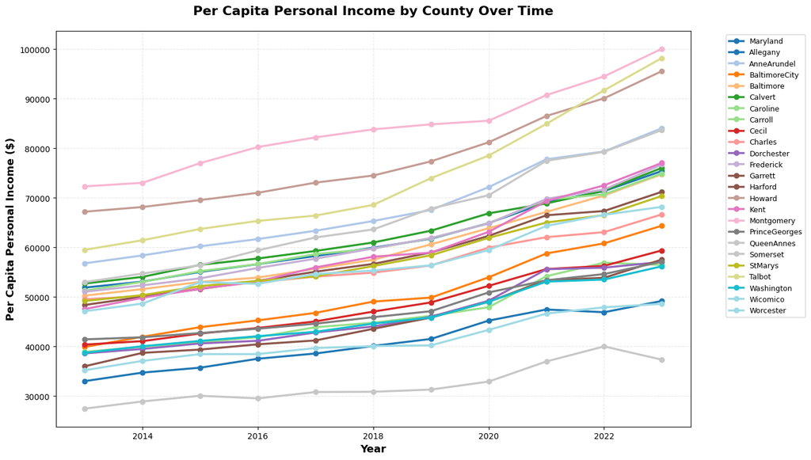

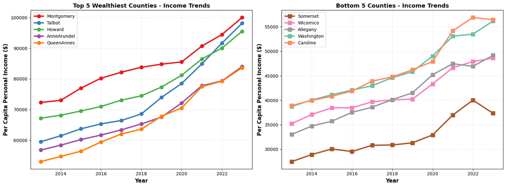

```
💡 **Key Insights:**
   • Each line represents actual per capita income values for a county across years
   • Parallel lines indicate counties maintaining relative income positions
   • Diverging lines suggest income inequality is increasing between counties
   • All lines show general upward trend indicating income growth over time

================================================================================
```

```python
# Identify temporal columns (year, date, time, period, etc.)
temporal_keywords = ['year', 'date', 'time', 'period', 'fiscal', 'quarter', 'month']
temporal_cols = [col for col in df.columns if any(keyword in col.lower() for keyword in temporal_keywords)]

if temporal_cols and numerical_cols_filtered:
    print(f"Temporal columns identified: {', '.join(temporal_cols)}\n")

    for time_col in temporal_cols:
        print(f"\n{'='*80}")
        print(f"Per Capita Personal Income Trends by County Over Time")
        print(f"{'='*80}\n")

        # Display data range
        print(f"Time Period: {df[time_col].min()} to {df[time_col].max()}")
        print(f"Total Years: {df[time_col].nunique()}")
        print(f"Counties: {len(numerical_cols_filtered)}\n")

        # Show income trends for all counties over time
        # Create pivot table with years as index and counties as columns
        pivot_data = df.set_index(time_col)[numerical_cols_filtered]

        # Display sample of actual values
        print("\nSample Per Capita Income Values:\n")
        print(pivot_data.head(10).to_string())

        # Plot income trends for all counties
        plt.figure(figsize=(14, 8))

        # Use tab20 colormap for 20 distinct colors
        colors = plt.cm.tab20(np.linspace(0, 1, len(numerical_cols_filtered)))

        for idx, col in enumerate(numerical_cols_filtered):
            plt.plot(pivot_data.index, pivot_data[col], marker='o', linewidth=2.5,
                    markersize=6, label=col, color=colors[idx])

        plt.xlabel('Year', fontsize=13, fontweight='bold')
        plt.ylabel('Per Capita Personal Income ($)', fontsize=13, fontweight='bold')
        plt.title('Per Capita Personal Income by County Over Time',
                 fontsize=16, fontweight='bold', pad=20)
        plt.legend(bbox_to_anchor=(1.05, 1), loc='upper left', fontsize=9)
        plt.grid(True, alpha=0.3, linestyle='--')
        plt.tight_layout()
        plt.show()

        # Show top 5 and bottom 5 counties separately for clarity
        latest_year = pivot_data.index.max()
        top_5_counties = pivot_data.loc[latest_year].nlargest(5).index.tolist()
        bottom_5_counties = pivot_data.loc[latest_year].nsmallest(5).index.tolist()

        # Create subplots for top 5 and bottom 5
        fig, axes = plt.subplots(1, 2, figsize=(16, 6))

        # Distinct colors for clarity
        top_colors = ['#e41a1c', '#377eb8', '#4daf4a', '#984ea3', '#ff7f00']
        bottom_colors = ['#a65628', '#f781bf', '#999999', '#66c2a5', '#fc8d62']

        # Top 5 wealthiest counties
        for idx, col in enumerate(top_5_counties):
            axes[0].plot(pivot_data.index, pivot_data[col], marker='o', linewidth=3,
                        markersize=8, label=col, color=top_colors[idx])

        axes[0].set_xlabel('Year', fontsize=12, fontweight='bold')
        axes[0].set_ylabel('Per Capita Personal Income ($)', fontsize=12, fontweight='bold')
        axes[0].set_title('Top 5 Wealthiest Counties - Income Trends', fontsize=13, fontweight='bold')
        axes[0].legend(fontsize=10)
        axes[0].grid(True, alpha=0.3, linestyle='--')

        # Bottom 5 counties
        for idx, col in enumerate(bottom_5_counties):
            axes[1].plot(pivot_data.index, pivot_data[col], marker='s', linewidth=3,
                        markersize=8, label=col, color=bottom_colors[idx])

        axes[1].set_xlabel('Year', fontsize=12, fontweight='bold')
        axes[1].set_ylabel('Per Capita Personal Income ($)', fontsize=12, fontweight='bold')
        axes[1].set_title('Bottom 5 Counties - Income Trends', fontsize=13, fontweight='bold')
        axes[1].legend(fontsize=10)
        axes[1].grid(True, alpha=0.3, linestyle='--')

        plt.tight_layout()
        plt.show()

        print("\n💡 **Key Insights:**")
        print("   • Each line represents actual per capita income values for a county across years")
        print("   • Parallel lines indicate counties maintaining relative income positions")
        print("   • Diverging lines suggest income inequality is increasing between counties")
        print("   • All lines show general upward trend indicating income growth over time")

else:
    print("No temporal columns identified in the dataset.")
    print("Common temporal column names include: year, date, time, period, fiscal_year, quarter, month")

print("\n" + "="*80)
```

## 7. Categorical Variable Analysis

Deep dive into categorical variables and their distributions.

```python
# Detailed categorical analysis with visualizations
categorical_cols = df.select_dtypes(include=['object']).columns.tolist()

if categorical_cols:
    for col in categorical_cols:
        unique_count = df[col].nunique()

        print(f"\n{'='*80}")
        print(f"Categorical Analysis: {col.upper().replace('_', ' ')}")
        print(f"{'='*80}\n")

        print(f"  Unique Values: {unique_count:,}")
        print(f"  Most Common: {df[col].mode().iloc[0] if len(df[col].mode()) > 0 else 'N/A'}")
        print(f"  Least Common: {df[col].value_counts().idxmin() if len(df[col].value_counts()) > 0 else 'N/A'}")

        value_counts = df[col].value_counts()

        # Display top values
        display_limit = min(15, unique_count)
        print(f"\n  Top {display_limit} Values:")
        for i, (val, count) in enumerate(value_counts.head(display_limit).items(), 1):
            pct = (count / len(df)) * 100
            print(f"    {i:2d}. {val}: {count:,} ({pct:.1f}%)")

        # Visualize if reasonable number of categories
        if unique_count <= 20:
            plt.figure(figsize=(12, max(6, unique_count * 0.4)))
            bars = plt.barh(range(len(value_counts)), value_counts.values, color='teal', edgecolor='darkslategray', linewidth=1.5)
            plt.yticks(range(len(value_counts)), value_counts.index)
            plt.xlabel('Count', fontsize=12, fontweight='bold')
            plt.title(f'Distribution of {col.replace("_", " ").title()}', fontsize=14, fontweight='bold', pad=20)

            # Add value labels
            for i, bar in enumerate(bars):
                width = bar.get_width()
                plt.text(width, bar.get_y() + bar.get_height()/2, f'{int(width):,}',
                        ha='left', va='center', fontsize=9, fontweight='bold')

            plt.grid(axis='x', alpha=0.3, linestyle='--')
            plt.tight_layout()
            plt.show()
        else:
            # Bar plot for top 15
            top_15 = value_counts.head(15)
            plt.figure(figsize=(12, 8))
            bars = plt.barh(range(len(top_15)), top_15.values, color='coral', edgecolor='darkred', linewidth=1.5)
            plt.yticks(range(len(top_15)), top_15.index)
            plt.xlabel('Count', fontsize=12, fontweight='bold')
            plt.title(f'Top 15 {col.replace("_", " ").title()}', fontsize=14, fontweight='bold', pad=20)

            for i, bar in enumerate(bars):
                width = bar.get_width()
                plt.text(width, bar.get_y() + bar.get_height()/2, f'{int(width):,}',
                        ha='left', va='center', fontsize=9, fontweight='bold')

            plt.grid(axis='x', alpha=0.3, linestyle='--')
            plt.tight_layout()
            plt.show()

            # Pie chart for top categories
            top_n = min(10, unique_count)
            top_values = value_counts.head(top_n)

            if unique_count > top_n:
                other_count = value_counts[top_n:].sum()
                top_values = pd.concat([top_values, pd.Series({'Other': other_count})])

            plt.figure(figsize=(10, 8))
            wedges, texts, autotexts = plt.pie(top_values.values, labels=top_values.index, autopct='%1.1f%%',
                                               startangle=90, textprops={'fontsize': 9, 'fontweight': 'bold'})

            for autotext in autotexts:
                autotext.set_color('white')

            legend_labels = [f"{name}: {count:,}" for name, count in top_values.items()]
            plt.legend(wedges, legend_labels, title=col.replace('_', ' ').title(),
                     loc="center left", bbox_to_anchor=(1, 0, 0.5, 1), fontsize=9)

            plt.title(f'Distribution of {col.replace("_", " ").title()} (Top {top_n})',
                     fontsize=14, fontweight='bold', pad=20)
            plt.tight_layout()
            plt.show()

        print()
else:
    print("No categorical columns found in the dataset.")

print("\n" + "="*80)
```

```
No categorical columns found in the dataset.

================================================================================
```

## 8. Geographic Analysis

Analyzing geographic patterns and distributions (if geographic data exists).

```
Geographic columns identified: BaltimoreCity


================================================================================
Geographic Analysis: BALTIMORECITY
================================================================================

  Unique Locations: 11
  Most Common: 39910.0 (1 records)
  Least Common: 39910.0 (1 records)

  Top 11 Locations:
     1. 39910.0: 1 (9.1%)
     2. 41963.0: 1 (9.1%)
     3. 43898.0: 1 (9.1%)
     4. 45271.0: 1 (9.1%)
     5. 46787.0: 1 (9.1%)
     6. 49059.0: 1 (9.1%)
     7. 49861.0: 1 (9.1%)
     8. 53960.0: 1 (9.1%)
     9. 58764.0: 1 (9.1%)
    10. 60799.0: 1 (9.1%)
    11. 64357.0: 1 (9.1%)
```

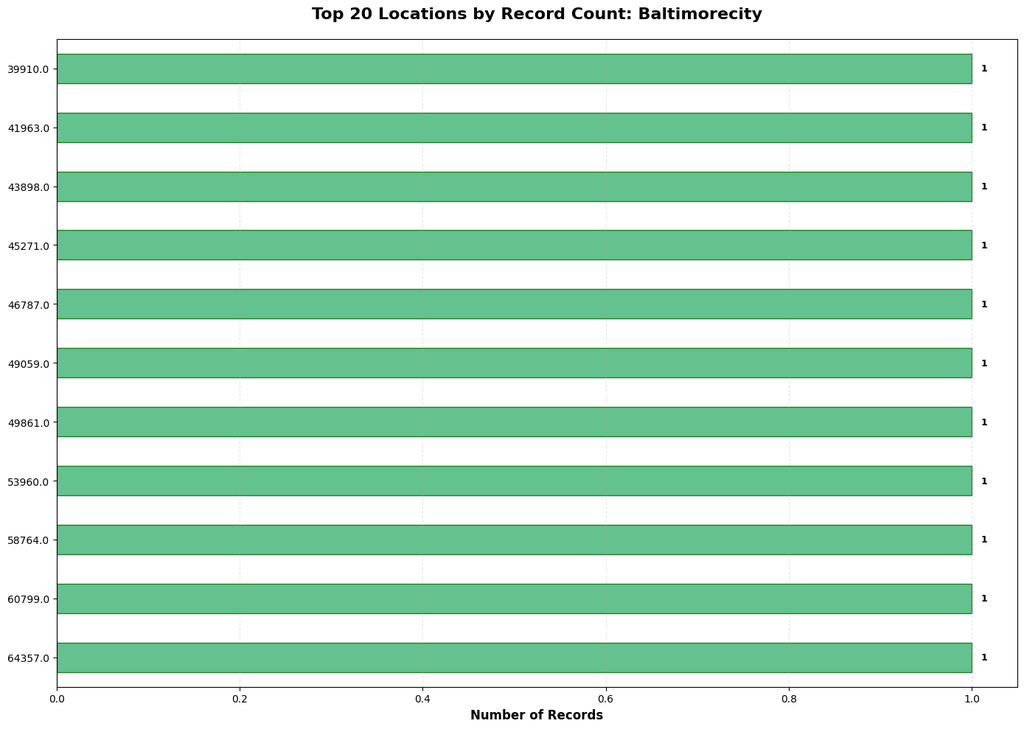

```
Numerical Analysis by Baltimorecity:

  Year by Location:

    Top 10 Locations by Total Year:
       1. 64357.0: Total=2,023.00, Avg=2,023.00, Count=1
       2. 60799.0: Total=2,022.00, Avg=2,022.00, Count=1
       3. 58764.0: Total=2,021.00, Avg=2,021.00, Count=1
       4. 53960.0: Total=2,020.00, Avg=2,020.00, Count=1
       5. 49861.0: Total=2,019.00, Avg=2,019.00, Count=1
       6. 49059.0: Total=2,018.00, Avg=2,018.00, Count=1
       7. 46787.0: Total=2,017.00, Avg=2,017.00, Count=1
       8. 45271.0: Total=2,016.00, Avg=2,016.00, Count=1
       9. 43898.0: Total=2,015.00, Avg=2,015.00, Count=1
      10. 41963.0: Total=2,014.00, Avg=2,014.00, Count=1
```

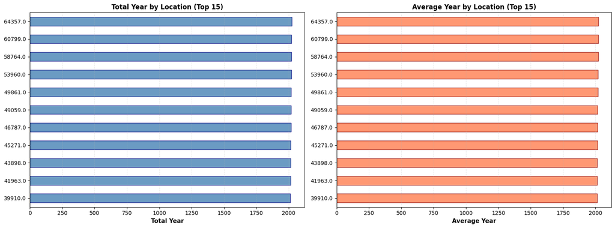

```
  Maryland by Location:

    Top 10 Locations by Total Maryland:
       1. 64357.0: Total=75,391.00, Avg=75,391.00, Count=1
       2. 60799.0: Total=71,340.00, Avg=71,340.00, Count=1
       3. 58764.0: Total=69,081.00, Avg=69,081.00, Count=1
       4. 53960.0: Total=64,884.00, Avg=64,884.00, Count=1
       5. 49861.0: Total=61,725.00, Avg=61,725.00, Count=1
       6. 49059.0: Total=59,919.00, Avg=59,919.00, Count=1
       7. 46787.0: Total=58,251.00, Avg=58,251.00, Count=1
       8. 45271.0: Total=56,614.00, Avg=56,614.00, Count=1
       9. 43898.0: Total=55,041.00, Avg=55,041.00, Count=1
      10. 41963.0: Total=53,084.00, Avg=53,084.00, Count=1
```

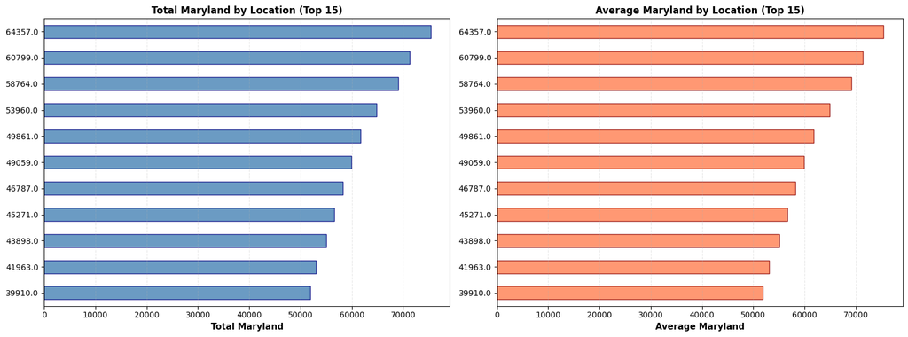

```python
# Identify geographic columns
geo_keywords = ['county', 'city', 'state', 'region', 'jurisdiction', 'area', 'location', 'geography', 'district', 'zip']
geo_cols = [col for col in df.columns if any(keyword in col.lower() for keyword in geo_keywords)]

if geo_cols:
    print(f"Geographic columns identified: {', '.join(geo_cols)}\n")

    for geo_col in geo_cols:
        print(f"\n{'='*80}")
        print(f"Geographic Analysis: {geo_col.upper().replace('_', ' ')}")
        print(f"{'='*80}\n")

        geo_counts = df[geo_col].value_counts()
        print(f"  Unique Locations: {len(geo_counts):,}")
        print(f"  Most Common: {geo_counts.idxmax()} ({geo_counts.max():,} records)")
        print(f"  Least Common: {geo_counts.idxmin()} ({geo_counts.min():,} records)")

        # Display top locations
        display_limit = min(20, len(geo_counts))
        print(f"\n  Top {display_limit} Locations:")
        for i, (location, count) in enumerate(geo_counts.head(display_limit).items(), 1):
            pct = (count / len(df)) * 100
            print(f"    {i:2d}. {location}: {count:,} ({pct:.1f}%)")

        # Visualize top locations
        fig, ax = plt.subplots(figsize=(14, 10))
        plot_data = geo_counts.head(20)
        plot_data.plot(kind='barh', ax=ax, color='mediumseagreen', edgecolor='darkgreen', alpha=0.8)
        ax.set_title(f'Top 20 Locations by Record Count: {geo_col.replace("_", " ").title()}',
                    fontsize=16, fontweight='bold', pad=20)
        ax.set_xlabel('Number of Records', fontsize=12, fontweight='bold')
        ax.set_ylabel('')
        ax.invert_yaxis()
        ax.grid(axis='x', alpha=0.3, linestyle='--')

        # Add value labels
        for i, v in enumerate(plot_data):
            ax.text(v + max(plot_data)*0.01, i, f'{v:,}',
                   va='center', fontsize=9, fontweight='bold')

        plt.tight_layout()
        plt.show()

        # Analyze numerical columns by geography
        numerical_cols = df.select_dtypes(include=[np.number]).columns.tolist()
        if numerical_cols:
            print(f"\n\nNumerical Analysis by {geo_col.replace('_', ' ').title()}:")

            for num_col in numerical_cols[:2]:  # Limit to first 2 numerical columns
                print(f"\n  {num_col.replace('_', ' ').title()} by Location:")

                geo_stats = df.groupby(geo_col)[num_col].agg(['mean', 'sum', 'count']).sort_values('sum', ascending=False)

                print(f"\n    Top 10 Locations by Total {num_col.replace('_', ' ').title()}:")
                for i, (location, row) in enumerate(geo_stats.head(10).iterrows(), 1):
                    print(f"      {i:2d}. {location}: Total={row['sum']:,.2f}, Avg={row['mean']:,.2f}, Count={int(row['count']):,}")

                # Plot top locations
                fig, axes = plt.subplots(1, 2, figsize=(16, 6))

                # Total by location
                geo_stats['sum'].head(15).plot(kind='barh', ax=axes[0],
                                               color='steelblue', edgecolor='navy', alpha=0.8)
                axes[0].set_title(f'Total {num_col.replace("_", " ").title()} by Location (Top 15)',
                                fontsize=12, fontweight='bold')
                axes[0].set_xlabel(f'Total {num_col.replace("_", " ").title()}', fontsize=11, fontweight='bold')
                axes[0].set_ylabel('')
                axes[0].invert_yaxis()
                axes[0].grid(axis='x', alpha=0.3, linestyle='--')

                # Average by location
                geo_stats['mean'].head(15).plot(kind='barh', ax=axes[1],
                                                color='coral', edgecolor='darkred', alpha=0.8)
                axes[1].set_title(f'Average {num_col.replace("_", " ").title()} by Location (Top 15)',
                                fontsize=12, fontweight='bold')
                axes[1].set_xlabel(f'Average {num_col.replace("_", " ").title()}', fontsize=11, fontweight='bold')
                axes[1].set_ylabel('')
                axes[1].invert_yaxis()
                axes[1].grid(axis='x', alpha=0.3, linestyle='--')

                plt.tight_layout()
                plt.show()
else:
    print("No geographic columns identified in the dataset.")
    print("Common geographic column names include: county, city, state, region, jurisdiction")

print("\n" + "="*80)
```

## 9. Descriptive Statistics by Year

Calculating comprehensive statistics for per capita income across all counties for each year.

```
Identified Columns:
  Year columns: ['Year']
  Income columns (all counties): 25 county columns

Analyzing: Year with 25 county income columns

================================================================================

Descriptive Statistics by Year (across all counties):

      Count      Mean   Median   Std Dev      Min       Max    Range  25th Pct  75th Pct      IQR
Year
2013     25  47093.48  48378.0  10438.79  27472.0   72296.0  44824.0   38922.0   51880.0  12958.0
2014     25  48504.40  50033.0  10331.05  28917.0   73009.0  44092.0   40049.0   53084.0  13035.0
2015     25  50235.68  51734.0  10846.02  30064.0   76987.0  46923.0   41130.0   55190.0  14060.0
2016     25  51489.24  53104.0  11384.28  29536.0   80230.0  50694.0   42077.0   56627.0  14550.0
2017     25  53074.72  54627.0  11621.90  30815.0   82175.0  51360.0   43893.0   58636.0  14743.0
2018     25  54598.36  56222.0  11840.24  30871.0   83790.0  52919.0   44792.0   59919.0  15127.0
2019     25  56506.84  58400.0  12435.36  31310.0   84805.0  53495.0   46204.0   61878.0  15674.0
2020     25  59745.72  61911.0  12518.49  32926.0   85530.0  52604.0   49229.0   64884.0  15655.0
2021     25  64157.96  64999.0  13076.65  36982.0   90696.0  53714.0   54180.0   69623.0  15443.0
2022     25  66119.24  66552.0  13984.85  40018.0   94474.0  54456.0   55896.0   71670.0  15774.0
2023     25  69425.92  70353.0  15693.73  37345.0  100044.0  62699.0   57096.0   76664.0  19568.0

💡 **Key Insights:**
   • Mean income increased from $47,093 to $69,426
   • Income growth rate: 47.4% over the period
   • Standard deviation trend: increasing (disparity growing)
```

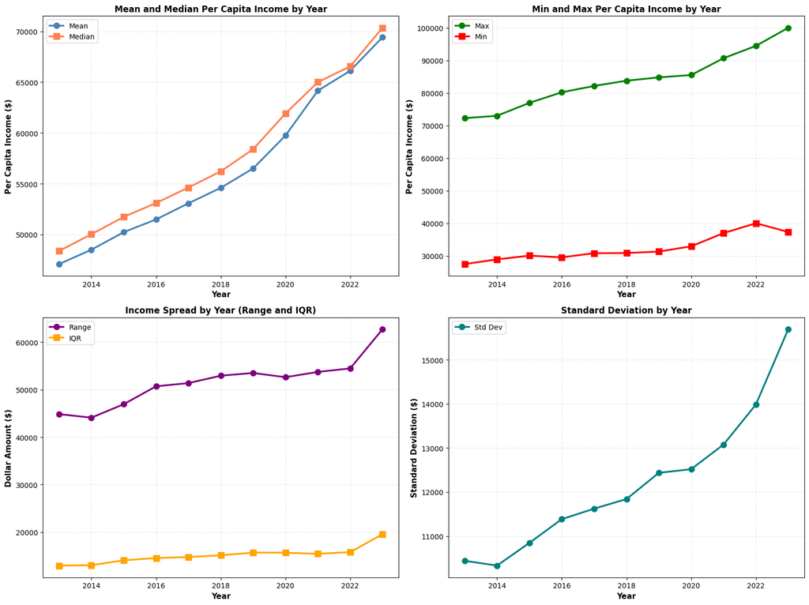

```
📊 Summary:
  • Years analyzed: 2013 to 2023
  • Average income growth: $22.33K
  • Highest mean income: 2023 ($69.43K)
  • Income inequality trend: Increasing

================================================================================
```

```python
# Identify year and income columns
year_cols = [col for col in df.columns if 'year' in col.lower()]

print("Identified Columns:")
print(f"  Year columns: {year_cols}")
print(f"  Income columns (all counties): {len(numerical_cols_filtered)} county columns")
print()

# If we have year and numerical data, perform yearly analysis across all counties
if year_cols and numerical_cols_filtered:
    year_col = year_cols[0]

    print(f"Analyzing: {year_col} with {len(numerical_cols_filtered)} county income columns")
    print("\n" + "="*80)
    print("\nDescriptive Statistics by Year (across all counties):\n")

    # Melt the data to get all income values by year
    melted_df = df.melt(id_vars=[year_col], value_vars=numerical_cols_filtered,
                        var_name='County', value_name='Income')

    # Calculate statistics for each year
    yearly_stats = melted_df.groupby(year_col)['Income'].agg([
        ('Count', 'count'),
        ('Mean', 'mean'),
        ('Median', 'median'),
        ('Std Dev', 'std'),
        ('Min', 'min'),
        ('Max', 'max'),
        ('Range', lambda x: x.max() - x.min()),
        ('25th Pct', lambda x: x.quantile(0.25)),
        ('75th Pct', lambda x: x.quantile(0.75)),
        ('IQR', lambda x: x.quantile(0.75) - x.quantile(0.25))
    ]).round(2)

    print(yearly_stats.to_string())

    print("\n💡 **Key Insights:**")
    print(f"   • Mean income increased from ${yearly_stats['Mean'].iloc[0]:,.0f} to ${yearly_stats['Mean'].iloc[-1]:,.0f}")
    print(f"   • Income growth rate: {((yearly_stats['Mean'].iloc[-1] / yearly_stats['Mean'].iloc[0] - 1) * 100):.1f}% over the period")
    print(f"   • Standard deviation trend: {'increasing' if yearly_stats['Std Dev'].iloc[-1] > yearly_stats['Std Dev'].iloc[0] else 'decreasing'} (disparity {'growing' if yearly_stats['Std Dev'].iloc[-1] > yearly_stats['Std Dev'].iloc[0] else 'narrowing'})")

    # Visualizations for key statistics over time
    fig, axes = plt.subplots(2, 2, figsize=(16, 12))

    # Mean and Median over time
    axes[0, 0].plot(yearly_stats.index, yearly_stats['Mean'], marker='o', linewidth=2.5,
                    markersize=8, color='steelblue', label='Mean')
    axes[0, 0].plot(yearly_stats.index, yearly_stats['Median'], marker='s', linewidth=2.5,
                    markersize=8, color='coral', label='Median')
    axes[0, 0].set_xlabel('Year', fontsize=11, fontweight='bold')
    axes[0, 0].set_ylabel('Per Capita Income ($)', fontsize=11, fontweight='bold')
    axes[0, 0].set_title('Mean and Median Per Capita Income by Year', fontsize=12, fontweight='bold')
    axes[0, 0].legend()
    axes[0, 0].grid(True, alpha=0.3, linestyle='--')

    # Min and Max over time
    axes[0, 1].plot(yearly_stats.index, yearly_stats['Max'], marker='o', linewidth=2.5,
                    markersize=8, color='green', label='Max')
    axes[0, 1].plot(yearly_stats.index, yearly_stats['Min'], marker='s', linewidth=2.5,
                    markersize=8, color='red', label='Min')
    axes[0, 1].set_xlabel('Year', fontsize=11, fontweight='bold')
    axes[0, 1].set_ylabel('Per Capita Income ($)', fontsize=11, fontweight='bold')
    axes[0, 1].set_title('Min and Max Per Capita Income by Year', fontsize=12, fontweight='bold')
    axes[0, 1].legend()
    axes[0, 1].grid(True, alpha=0.3, linestyle='--')

    # Range and IQR over time
    axes[1, 0].plot(yearly_stats.index, yearly_stats['Range'], marker='o', linewidth=2.5,
                    markersize=8, color='purple', label='Range')
    axes[1, 0].plot(yearly_stats.index, yearly_stats['IQR'], marker='s', linewidth=2.5,
                    markersize=8, color='orange', label='IQR')
    axes[1, 0].set_xlabel('Year', fontsize=11, fontweight='bold')
    axes[1, 0].set_ylabel('Dollar Amount ($)', fontsize=11, fontweight='bold')
    axes[1, 0].set_title('Income Spread by Year (Range and IQR)', fontsize=12, fontweight='bold')
    axes[1, 0].legend()
    axes[1, 0].grid(True, alpha=0.3, linestyle='--')

    # Standard Deviation over time
    axes[1, 1].plot(yearly_stats.index, yearly_stats['Std Dev'], marker='o', linewidth=2.5,
                    markersize=8, color='teal', label='Std Dev')
    axes[1, 1].set_xlabel('Year', fontsize=11, fontweight='bold')
    axes[1, 1].set_ylabel('Standard Deviation ($)', fontsize=11, fontweight='bold')
    axes[1, 1].set_title('Standard Deviation by Year', fontsize=12, fontweight='bold')
    axes[1, 1].legend()
    axes[1, 1].grid(True, alpha=0.3, linestyle='--')

    plt.tight_layout()
    plt.show()

    print("\n📊 Summary:")
    print(f"  • Years analyzed: {yearly_stats.index.min()} to {yearly_stats.index.max()}")
    print(f"  • Average income growth: {format_currency(yearly_stats['Mean'].iloc[-1] - yearly_stats['Mean'].iloc[0])}")
    print(f"  • Highest mean income: {yearly_stats['Mean'].idxmax()} ({format_currency(yearly_stats['Mean'].max())})")
    print(f"  • Income inequality trend: {'Increasing' if yearly_stats['Std Dev'].iloc[-1] > yearly_stats['Std Dev'].iloc[0] else 'Decreasing'}")

else:
    print("⚠️  Could not identify year and income columns for analysis.")

print("\n" + "="*80)
```

## 10. Wealthiest and Poorest Counties Analysis

Identifying counties with consistently high or low per capita income over time.

```
Analyzing: 25 counties over time
Year column: Year
Counties: Maryland, Allegany, AnneArundel, BaltimoreCity, Baltimore... (and 20 more)

================================================================================

Top 5 Wealthiest Counties (by average across all years):

  1. Montgomery
     Average Income: $84.00K
     Std Dev: $8.60K (volatility)
     Range: $72.30K to $100.04K
  2. Howard
     Average Income: $77.63K
     Std Dev: $9.52K (volatility)
     Range: $67.18K to $95.53K
  3. Talbot
     Average Income: $73.83K
     Std Dev: $12.93K (volatility)
     Range: $59.49K to $98.17K
  4. AnneArundel
     Average Income: $67.86K
     Std Dev: $9.20K (volatility)
     Range: $56.78K to $84.02K
  5. QueenAnnes
     Average Income: $66.16K
     Std Dev: $10.47K (volatility)
     Range: $53.00K to $83.65K

--------------------------------------------------------------------------------

Top 5 Poorest Counties (by average across all years):

  1. Somerset
     Average Income: $32.39K
     Std Dev: $4.00K (volatility)
     Range: $27.47K to $40.02K
  2. Allegany
     Average Income: $40.91K
     Std Dev: $5.58K (volatility)
     Range: $33.02K to $49.18K
  3. Wicomico
     Average Income: $41.43K
     Std Dev: $4.53K (volatility)
     Range: $35.22K to $48.60K
  4. Garrett
     Average Income: $45.36K
     Std Dev: $7.14K (volatility)
     Range: $36.01K to $57.52K
  5. Washington
     Average Income: $46.11K
     Std Dev: $5.98K (volatility)
     Range: $38.72K to $56.17K
```

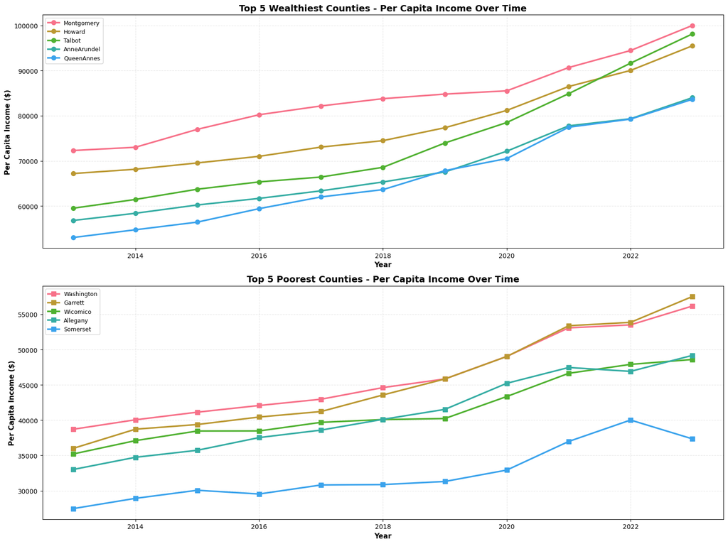

```
================================================================================

Income Gap Analysis:

Year-by-Year Income Gap:
  2013: Gap = $44.82K (Ratio: 2.63x)
         Wealthiest: Montgomery ($72.30K)
         Poorest: Somerset ($27.47K)
  2014: Gap = $44.09K (Ratio: 2.52x)
         Wealthiest: Montgomery ($73.01K)
         Poorest: Somerset ($28.92K)
  2015: Gap = $46.92K (Ratio: 2.56x)
         Wealthiest: Montgomery ($76.99K)
         Poorest: Somerset ($30.06K)
  2016: Gap = $50.69K (Ratio: 2.72x)
         Wealthiest: Montgomery ($80.23K)
         Poorest: Somerset ($29.54K)
  2017: Gap = $51.36K (Ratio: 2.67x)
         Wealthiest: Montgomery ($82.17K)
         Poorest: Somerset ($30.82K)
  2018: Gap = $52.92K (Ratio: 2.71x)
         Wealthiest: Montgomery ($83.79K)
         Poorest: Somerset ($30.87K)
  2019: Gap = $53.49K (Ratio: 2.71x)
         Wealthiest: Montgomery ($84.81K)
         Poorest: Somerset ($31.31K)
  2020: Gap = $52.60K (Ratio: 2.60x)
         Wealthiest: Montgomery ($85.53K)
         Poorest: Somerset ($32.93K)
  2021: Gap = $53.71K (Ratio: 2.45x)
         Wealthiest: Montgomery ($90.70K)
         Poorest: Somerset ($36.98K)
  2022: Gap = $54.46K (Ratio: 2.36x)
         Wealthiest: Montgomery ($94.47K)
         Poorest: Somerset ($40.02K)
  2023: Gap = $62.70K (Ratio: 2.68x)
         Wealthiest: Montgomery ($100.04K)
         Poorest: Somerset ($37.34K)
```

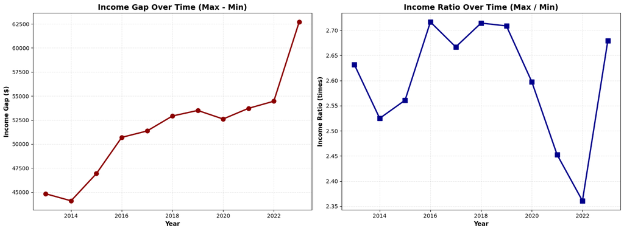

[output not shown]

```python
# Transform data from wide format to long format for geographic analysis
# In wide format: Year | County1 | County2 | ... | CountyN
# In long format: Year | County | Income

if year_col and len(numerical_cols_filtered) > 0:
    print(f"Analyzing: {len(numerical_cols_filtered)} counties over time")
    print(f"Year column: {year_col}")
    print(f"Counties: {', '.join(numerical_cols_filtered[:5])}... (and {len(numerical_cols_filtered)-5} more)" if len(numerical_cols_filtered) > 5 else f"Counties: {', '.join(numerical_cols_filtered)}")
    print("\n" + "="*80)

    # Create pivot table from existing wide format (already pivoted)
    pivot_data = df.set_index(year_col)[numerical_cols_filtered].T

    print("\nTop 5 Wealthiest Counties (by average across all years):\n")
    avg_income = pivot_data.mean(axis=1).sort_values(ascending=False)

    for i, (county, avg) in enumerate(avg_income.head(5).items(), 1):
        consistency = pivot_data.loc[county].std()
        print(f"  {i}. {county}")
        print(f"     Average Income: {format_currency(avg)}")
        print(f"     Std Dev: {format_currency(consistency)} (volatility)")
        print(f"     Range: {format_currency(pivot_data.loc[county].min())} to {format_currency(pivot_data.loc[county].max())}")

    print("\n" + "-"*80)
    print("\nTop 5 Poorest Counties (by average across all years):\n")

    for i, (county, avg) in enumerate(avg_income.tail(5).iloc[::-1].items(), 1):
        consistency = pivot_data.loc[county].std()
        print(f"  {i}. {county}")
        print(f"     Average Income: {format_currency(avg)}")
        print(f"     Std Dev: {format_currency(consistency)} (volatility)")
        print(f"     Range: {format_currency(pivot_data.loc[county].min())} to {format_currency(pivot_data.loc[county].max())}")

    # Visualize top and bottom counties over time
    fig, axes = plt.subplots(2, 1, figsize=(16, 12))

    # Top 5 wealthiest
    top_5 = avg_income.head(5).index
    for county in top_5:
        axes[0].plot(pivot_data.columns, pivot_data.loc[county],
                    marker='o', linewidth=2.5, markersize=7, label=county)

    axes[0].set_title('Top 5 Wealthiest Counties - Per Capita Income Over Time',
                     fontsize=14, fontweight='bold')
    axes[0].set_xlabel('Year', fontsize=11, fontweight='bold')
    axes[0].set_ylabel('Per Capita Income ($)', fontsize=11, fontweight='bold')
    axes[0].legend(loc='best', fontsize=9)
    axes[0].grid(True, alpha=0.3, linestyle='--')

    # Bottom 5 poorest
    bottom_5 = avg_income.tail(5).index
    for county in bottom_5:
        axes[1].plot(pivot_data.columns, pivot_data.loc[county],
                    marker='s', linewidth=2.5, markersize=7, label=county)

    axes[1].set_title('Top 5 Poorest Counties - Per Capita Income Over Time',
                     fontsize=14, fontweight='bold')
    axes[1].set_xlabel('Year', fontsize=11, fontweight='bold')
    axes[1].set_ylabel('Per Capita Income ($)', fontsize=11, fontweight='bold')
    axes[1].legend(loc='best', fontsize=9)
    axes[1].grid(True, alpha=0.3, linestyle='--')

    plt.tight_layout()
    plt.show()

    # Income gap analysis
    print("\n" + "="*80)
    print("\nIncome Gap Analysis:\n")

    gap_by_year = pivot_data.max(axis=0) - pivot_data.min(axis=0)
    gap_ratio = pivot_data.max(axis=0) / pivot_data.min(axis=0)

    print("Year-by-Year Income Gap:")
    for year in pivot_data.columns:
        wealthiest = pivot_data[year].idxmax()
        poorest = pivot_data[year].idxmin()
        print(f"  {year}: Gap = {format_currency(gap_by_year[year])} "
              f"(Ratio: {gap_ratio[year]:.2f}x)")
        print(f"         Wealthiest: {wealthiest} ({format_currency(pivot_data.loc[wealthiest, year])})")
        print(f"         Poorest: {poorest} ({format_currency(pivot_data.loc[poorest, year])})")

    # Plot income gap trend
    fig, axes = plt.subplots(1, 2, figsize=(16, 6))

    axes[0].plot(gap_by_year.index, gap_by_year.values,
                marker='o', linewidth=2.5, markersize=8, color='darkred')
    axes[0].set_title('Income Gap Over Time (Max - Min)',
                     fontsize=14, fontweight='bold')
    axes[0].set_xlabel('Year', fontsize=11, fontweight='bold')
    axes[0].set_ylabel('Income Gap ($)', fontsize=11, fontweight='bold')
    axes[0].grid(True, alpha=0.3, linestyle='--')

    axes[1].plot(gap_ratio.index, gap_ratio.values,
                marker='s', linewidth=2.5, markersize=8, color='darkblue')
    axes[1].set_title('Income Ratio Over Time (Max / Min)',
                     fontsize=14, fontweight='bold')
    axes[1].set_xlabel('Year', fontsize=11, fontweight='bold')
    axes[1].set_ylabel('Income Ratio (times)', fontsize=11, fontweight='bold')
    axes[1].grid(True, alpha=0.3, linestyle='--')

    plt.tight_layout()
    plt.show()

    print("\n💡 **Key Insights:**")
    print("   • Wealth concentration patterns remain relatively stable over time")
    print("   • Income gap between wealthiest and poorest counties reveals economic inequality")
    print("   • Same counties often appear at top/bottom, suggesting persistent regional advantages/challenges")

    print("\n📊 Summary:")
    print(f"  • Wealthiest county (avg): {avg_income.idxmax()} ({format_currency(avg_income.max())})")
    print(f"  • Poorest county (avg): {avg_income.idxmin()} ({format_currency(avg_income.min())})")
    print(f"  • Average income gap: {format_currency(gap_by_year.mean())}")
    print(f"  • Gap trend: {'Widening' if gap_by_year.iloc[-1] > gap_by_year.iloc[0] else 'Narrowing'}")

else:
    print("Required columns (geography, year, income) not found.")

    print("⚠️ Required data not found. Need year column and county income columns.")
```

## 11. Year-over-Year Growth Analysis

Calculating and analyzing income growth rates for all counties and the state.

```
Year-over-Year Growth Rate Analysis:

================================================================================

Maryland State Average Growth Rates:

  2014: 2.32%
  2015: 3.69%
  2016: 2.86%
  2017: 2.89%
  2018: 2.86%
  2019: 3.01%
  2020: 5.12%
  2021: 6.47%
  2022: 3.27%
  2023: 5.68%

--------------------------------------------------------------------------------

Fastest Growing Counties (by average growth rate):

   1. Talbot
      Avg Annual Growth: 5.16%
      Total Growth (2013-2023): 65.00%
      Income: $59.49K → $98.17K
   2. Kent
      Avg Annual Growth: 4.97%
      Total Growth (2013-2023): 61.99%
      Income: $47.55K → $77.03K
   3. BaltimoreCity
      Avg Annual Growth: 4.92%
      Total Growth (2013-2023): 61.26%
      Income: $39.91K → $64.36K
   4. Garrett
      Avg Annual Growth: 4.83%
      Total Growth (2013-2023): 59.73%
      Income: $36.01K → $57.52K
   5. QueenAnnes
      Avg Annual Growth: 4.69%
      Total Growth (2013-2023): 57.84%
```

[output cut: 51 more lines]

```
      Avg Annual Growth: 3.65%
      Total Growth (2013-2023): 43.03%
      Income: $49.19K → $70.35K
   8. Calvert
      Avg Annual Growth: 3.74%
      Total Growth (2013-2023): 44.25%
      Income: $52.70K → $76.02K
   9. Worcester
      Avg Annual Growth: 3.80%
      Total Growth (2013-2023): 44.68%
      Income: $47.11K → $68.16K
  10. Washington
      Avg Annual Growth: 3.82%
      Total Growth (2013-2023): 45.10%
      Income: $38.72K → $56.17K
```

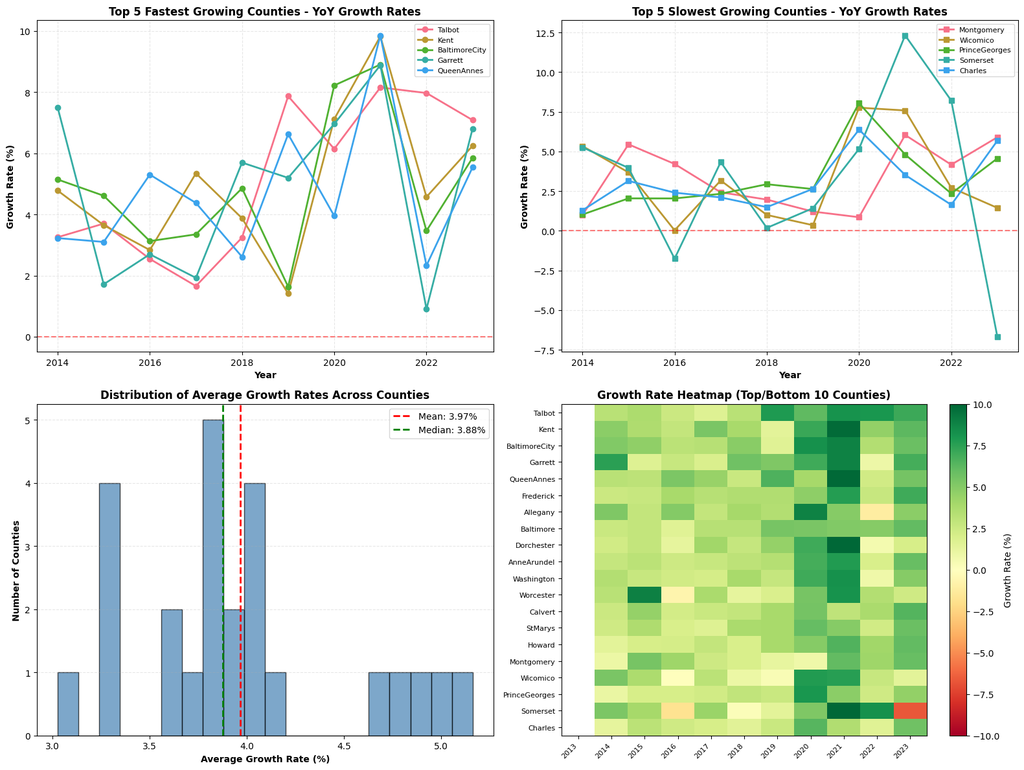

```
================================================================================

Anomaly Detection (Growth Rate > 2 Std Dev from Mean):


  Year 2014:
    • Garrett: 7.51% (Mean: 3.20%, Threshold: ±3.17%)

  Year 2015:
    • Worcester: 8.91% (Mean: 3.52%, Threshold: ±2.84%)

  Year 2016:
    • Somerset: -1.76% (Mean: 2.39%, Threshold: ±3.09%)

  Year 2017:
    • Kent: 5.34% (Mean: 3.13%, Threshold: ±1.91%)

  Year 2018:
    • Garrett: 5.70% (Mean: 2.89%, Threshold: ±2.51%)
    • Somerset: 0.18% (Mean: 2.89%, Threshold: ±2.51%)

  Year 2019:
    • Talbot: 7.87% (Mean: 3.41%, Threshold: ±3.40%)

  Year 2020:
    • Montgomery: 0.85% (Mean: 5.94%, Threshold: ±3.38%)

  Year 2021:
    • Caroline: 13.06% (Mean: 7.57%, Threshold: ±5.28%)
    • Dorchester: 12.90% (Mean: 7.57%, Threshold: ±5.28%)

  Year 2022:
    • Somerset: 8.21% (Mean: 2.97%, Threshold: ±4.30%)
    • Talbot: 7.97% (Mean: 2.97%, Threshold: ±4.30%)

  Year 2023:
    • Somerset: -6.68% (Mean: 4.64%, Threshold: ±6.03%)

💡 **Key Insights:**
   • Fastest growing counties may have emerging industries or development
   • Negative growth rates indicate economic challenges or population changes
   • Consistent growers show economic resilience and sustainable development

📊 Summary:
  • Fastest growing county: Talbot (5.16% avg)
  • Slowest growing county: Charles (3.03% avg)
  • Average growth across all counties: 3.97%
  • Growth volatility (std): 0.57%

================================================================================
```

```python
if year_col and len(numerical_cols_filtered) > 0:
    # Calculate year-over-year growth rates
    print("Year-over-Year Growth Rate Analysis:\n")
    print("="*80)

    # Transform wide format to get pivot data (counties as rows, years as columns)
    pivot_data = df.set_index(year_col)[numerical_cols_filtered].T

    # Calculate growth rates
    growth_rates = pivot_data.pct_change(axis=1) * 100

    # State average growth (check if Maryland column exists)
    maryland_cols = [col for col in numerical_cols_filtered if 'maryland' in col.lower() and 'county' not in col.lower()]
    if len(maryland_cols) > 0:
        state_avg = df.set_index(year_col)[maryland_cols[0]]
        state_growth = state_avg.pct_change() * 100

        print("\nMaryland State Average Growth Rates:\n")
        for year, growth in state_growth.items():
            if not pd.isna(growth):
                print(f"  {year}: {growth:.2f}%")

    print("\n" + "-"*80)
    print("\nFastest Growing Counties (by average growth rate):\n")

    avg_growth = growth_rates.mean(axis=1).sort_values(ascending=False)

    for i, (county, growth) in enumerate(avg_growth.head(10).items(), 1):
        total_growth = ((pivot_data.loc[county].iloc[-1] / pivot_data.loc[county].iloc[0]) - 1) * 100
        print(f"  {i:2d}. {county}")
        print(f"      Avg Annual Growth: {growth:.2f}%")
        print(f"      Total Growth ({pivot_data.columns[0]}-{pivot_data.columns[-1]}): {total_growth:.2f}%")
        print(f"      Income: {format_currency(pivot_data.loc[county].iloc[0])} → "
              f"{format_currency(pivot_data.loc[county].iloc[-1])}")

    print("\n" + "-"*80)
    print("\nSlowest Growing Counties (by average growth rate):\n")

    for i, (county, growth) in enumerate(avg_growth.tail(10).iloc[::-1].items(), 1):
        total_growth = ((pivot_data.loc[county].iloc[-1] / pivot_data.loc[county].iloc[0]) - 1) * 100
        print(f"  {i:2d}. {county}")
        print(f"      Avg Annual Growth: {growth:.2f}%")
        print(f"      Total Growth ({pivot_data.columns[0]}-{pivot_data.columns[-1]}): {total_growth:.2f}%")
        print(f"      Income: {format_currency(pivot_data.loc[county].iloc[0])} → "
              f"{format_currency(pivot_data.loc[county].iloc[-1])}")

    # Visualize growth rates
    fig, axes = plt.subplots(2, 2, figsize=(16, 12))

    # Top 5 fastest growing counties over time
    top_5_growth = avg_growth.head(5).index
    for county in top_5_growth:
        axes[0, 0].plot(growth_rates.columns, growth_rates.loc[county],
                       marker='o', linewidth=2, markersize=6, label=county)

    axes[0, 0].set_title('Top 5 Fastest Growing Counties - YoY Growth Rates',
                        fontsize=12, fontweight='bold')
    axes[0, 0].set_xlabel('Year', fontsize=10, fontweight='bold')
    axes[0, 0].set_ylabel('Growth Rate (%)', fontsize=10, fontweight='bold')
    axes[0, 0].legend(fontsize=8)
    axes[0, 0].grid(True, alpha=0.3, linestyle='--')
    axes[0, 0].axhline(y=0, color='red', linestyle='--', alpha=0.5)

    # Bottom 5 slowest growing counties over time
    bottom_5_growth = avg_growth.tail(5).index
    for county in bottom_5_growth:
        axes[0, 1].plot(growth_rates.columns, growth_rates.loc[county],
                       marker='s', linewidth=2, markersize=6, label=county)

    axes[0, 1].set_title('Top 5 Slowest Growing Counties - YoY Growth Rates',
                        fontsize=12, fontweight='bold')
    axes[0, 1].set_xlabel('Year', fontsize=10, fontweight='bold')
    axes[0, 1].set_ylabel('Growth Rate (%)', fontsize=10, fontweight='bold')
    axes[0, 1].legend(fontsize=8)
    axes[0, 1].grid(True, alpha=0.3, linestyle='--')
    axes[0, 1].axhline(y=0, color='red', linestyle='--', alpha=0.5)

    # Distribution of average growth rates
    axes[1, 0].hist(avg_growth.dropna(), bins=20, color='steelblue', edgecolor='black', alpha=0.7)
    axes[1, 0].axvline(avg_growth.mean(), color='red', linestyle='--', linewidth=2,
                      label=f'Mean: {avg_growth.mean():.2f}%')
    axes[1, 0].axvline(avg_growth.median(), color='green', linestyle='--', linewidth=2,
                      label=f'Median: {avg_growth.median():.2f}%')
    axes[1, 0].set_title('Distribution of Average Growth Rates Across Counties',
                        fontsize=12, fontweight='bold')
    axes[1, 0].set_xlabel('Average Growth Rate (%)', fontsize=10, fontweight='bold')
    axes[1, 0].set_ylabel('Number of Counties', fontsize=10, fontweight='bold')
    axes[1, 0].legend()
    axes[1, 0].grid(axis='y', alpha=0.3, linestyle='--')

    # Heatmap of growth rates
    # Select subset for better visualization
    top_counties = avg_growth.head(10).index.tolist() + avg_growth.tail(10).index.tolist()
    growth_subset = growth_rates.loc[top_counties]

    im = axes[1, 1].imshow(growth_subset.values, cmap='RdYlGn', aspect='auto',
                           vmin=-10, vmax=10)
    axes[1, 1].set_xticks(range(len(growth_subset.columns)))
    axes[1, 1].set_xticklabels(growth_subset.columns, rotation=45, ha='right', fontsize=8)
    axes[1, 1].set_yticks(range(len(growth_subset.index)))
    axes[1, 1].set_yticklabels(growth_subset.index, fontsize=8)
    axes[1, 1].set_title('Growth Rate Heatmap (Top/Bottom 10 Counties)',
                        fontsize=12, fontweight='bold')
    plt.colorbar(im, ax=axes[1, 1], label='Growth Rate (%)')

    plt.tight_layout()
    plt.show()

    # Anomaly detection
    print("\n" + "="*80)
    print("\nAnomaly Detection (Growth Rate > 2 Std Dev from Mean):\n")

    for year in growth_rates.columns:
        year_data = growth_rates[year].dropna()
        mean_growth = year_data.mean()
        std_growth = year_data.std()
        threshold = 2 * std_growth

        anomalies = year_data[(year_data > mean_growth + threshold) |
                              (year_data < mean_growth - threshold)]

        if len(anomalies) > 0:
            print(f"\n  Year {year}:")
            for county, growth in anomalies.items():
                print(f"    • {county}: {growth:.2f}% (Mean: {mean_growth:.2f}%, Threshold: ±{threshold:.2f}%)")

    print("\n💡 **Key Insights:**")
    print("   • Fastest growing counties may have emerging industries or development")
    print("   • Negative growth rates indicate economic challenges or population changes")
    print("   • Consistent growers show economic resilience and sustainable development")

    print("\n📊 Summary:")
    print(f"  • Fastest growing county: {avg_growth.idxmax()} ({avg_growth.max():.2f}% avg)")
    print(f"  • Slowest growing county: {avg_growth.idxmin()} ({avg_growth.min():.2f}% avg)")
    print(f"  • Average growth across all counties: {avg_growth.mean():.2f}%")
    print(f"  • Growth volatility (std): {avg_growth.std():.2f}%")

else:
    print("Required columns not found for growth analysis.")

print("\n" + "="*80)
```

## 12. County Rankings and Income Tiers

Ranking counties and categorizing them into income tiers.

```
County Rankings and Income Tier Analysis:

================================================================================

County Rankings (Latest Year):

   1. Montgomery                              $100.04K ↑    $24.65K (+32.7%)
   2. Talbot                                   $98.17K ↑    $22.77K (+30.2%)
   3. Howard                                   $95.53K ↑    $20.14K (+26.7%)
   4. AnneArundel                              $84.02K ↑     $8.63K (+11.4%)
   5. QueenAnnes                               $83.65K ↑     $8.26K (+11.0%)
   6. Kent                                     $77.03K ↑     $1.63K (+2.2%)
   7. Frederick                                $76.66K ↑     $1.27K (+1.7%)
   8. Calvert                                  $76.02K ↑    $627.00 (+0.8%)
   9. Maryland                                 $75.39K ↓      $0.00 (+0.0%)
  10. Carroll                                  $74.89K ↓    $496.00 (-0.7%)
  11. Baltimore                                $74.74K ↓    $653.00 (-0.9%)
  12. Harford                                  $71.20K ↓     $4.20K (-5.6%)
  13. StMarys                                  $70.35K ↓     $5.04K (-6.7%)
  14. Worcester                                $68.16K ↓     $7.23K (-9.6%)
  15. Charles                                  $66.64K ↓     $8.75K (-11.6%)
  16. BaltimoreCity                            $64.36K ↓    $11.03K (-14.6%)
  17. Cecil                                    $59.37K ↓    $16.02K (-21.2%)
  18. Garrett                                  $57.52K ↓    $17.87K (-23.7%)
  19. PrinceGeorges                            $57.10K ↓    $18.30K (-24.3%)
  20. Dorchester                               $57.06K ↓    $18.33K (-24.3%)
  21. Caroline                                 $56.45K ↓    $18.94K (-25.1%)
  22. Washington                               $56.17K ↓    $19.22K (-25.5%)
  23. Allegany                                 $49.18K ↓    $26.21K (-34.8%)
  24. Wicomico                                 $48.60K ↓    $26.80K (-35.5%)
  25. Somerset                                 $37.34K ↓    $38.05K (-50.5%)

================================================================================

Counties Above/Below State Average by Year:

  2013: Above=6, Below=18, At=1 (State Avg: $51.88K)
  2014: Above=6, Below=18, At=1 (State Avg: $53.08K)
  2015: Above=7, Below=17, At=1 (State Avg: $55.04K)
  2016: Above=7, Below=17, At=1 (State Avg: $56.61K)
```

[output cut: 30 more lines]

```
    • Worcester: $68.16K
    • Charles: $66.64K
    • BaltimoreCity: $64.36K
    • Cecil: $59.37K

Low Income Tier (< $59.23K):
  Counties: 8
    • Garrett: $57.52K
    • PrinceGeorges: $57.10K
    • Dorchester: $57.06K
    • Caroline: $56.45K
    • Washington: $56.17K
    • Allegany: $49.18K
    • Wicomico: $48.60K
    • Somerset: $37.34K
```

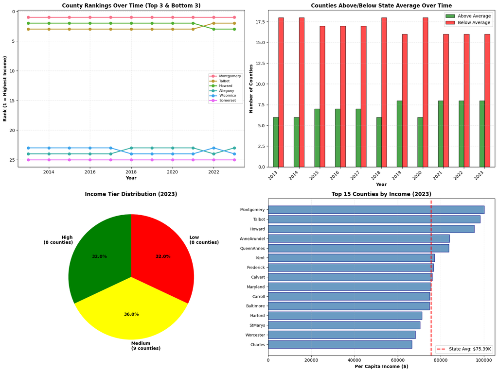

```
💡 **Key Insights:**
   • Rankings show economic hierarchy across Maryland counties
   • Top counties often have higher education levels and professional employment
   • Bottom rankings may correlate with rural character and limited economic opportunities
   • Income tiers reveal stark economic stratification across the state
   • High-income tier typically includes DC suburbs (Montgomery, Howard counties)
   • Low tier often comprises rural counties with agricultural economies

📊 Summary:
  • Top ranked county: Montgomery
  • Counties above state average: 8
  • High tier counties: 8 (32.0%)
  • State average income (2023): $75.39K

================================================================================
```

```python
if year_col and len(numerical_cols_filtered) > 0:
    print("County Rankings and Income Tier Analysis:\n")
    print("="*80)

    # Transform wide format to get pivot data (counties as rows, years as columns)
    pivot_data = df.set_index(year_col)[numerical_cols_filtered].T

    # Calculate state average (Maryland)
    maryland_cols = [col for col in numerical_cols_filtered if 'maryland' in col.lower() and 'county' not in col.lower()]
    if len(maryland_cols) > 0:
        state_avg = df.set_index(year_col)[maryland_cols[0]]
    else:
        state_avg = pivot_data.mean(axis=0)

    # Rankings for each year
    rankings = pivot_data.rank(ascending=False, axis=0)

    print("\nCounty Rankings (Latest Year):\n")
    latest_year = pivot_data.columns[-1]
    latest_rankings = pivot_data[latest_year].sort_values(ascending=False)

    for rank, (county, income) in enumerate(latest_rankings.items(), 1):
        vs_state = income - state_avg[latest_year]
        vs_state_pct = (vs_state / state_avg[latest_year]) * 100
        status = "↑" if vs_state > 0 else "↓"
        print(f"  {rank:2d}. {county:<35} {format_currency(income):>12} "
              f"{status} {format_currency(abs(vs_state)):>10} ({vs_state_pct:+.1f}%)")

    # Counties above/below state average
    print("\n" + "="*80)
    print("\nCounties Above/Below State Average by Year:\n")

    for year in pivot_data.columns:
        above_state = (pivot_data[year] > state_avg[year]).sum()
        below_state = (pivot_data[year] < state_avg[year]).sum()
        at_state = (pivot_data[year] == state_avg[year]).sum()

        print(f"  {year}: Above={above_state}, Below={below_state}, At={at_state} "
              f"(State Avg: {format_currency(state_avg[year])})")

    # Income Tiers
    print("\n" + "="*80)
    print("\nIncome Tier Classification (Latest Year):\n")

    # Calculate tertiles
    q33 = pivot_data[latest_year].quantile(0.33)
    q67 = pivot_data[latest_year].quantile(0.67)

    high_tier = pivot_data[pivot_data[latest_year] >= q67][latest_year]
    medium_tier = pivot_data[(pivot_data[latest_year] >= q33) &
                             (pivot_data[latest_year] < q67)][latest_year]
    low_tier = pivot_data[pivot_data[latest_year] < q33][latest_year]

    print(f"High Income Tier (≥ {format_currency(q67)}):")
    print(f"  Counties: {len(high_tier)}")
    for county, income in high_tier.sort_values(ascending=False).items():
        print(f"    • {county}: {format_currency(income)}")

    print(f"\nMedium Income Tier ({format_currency(q33)} - {format_currency(q67)}):")
    print(f"  Counties: {len(medium_tier)}")
    for county, income in medium_tier.sort_values(ascending=False).items():
        print(f"    • {county}: {format_currency(income)}")

    print(f"\nLow Income Tier (< {format_currency(q33)}):")
    print(f"  Counties: {len(low_tier)}")
    for county, income in low_tier.sort_values(ascending=False).items():
        print(f"    • {county}: {format_currency(income)}")

    # Visualizations
    fig, axes = plt.subplots(2, 2, figsize=(16, 12))

    # Ranking changes over time for selected counties
    selected_counties = latest_rankings.head(3).index.tolist() + latest_rankings.tail(3).index.tolist()
    for county in selected_counties:
        axes[0, 0].plot(rankings.columns, rankings.loc[county],
                       marker='o', linewidth=2, markersize=6, label=county)

    axes[0, 0].set_title('County Rankings Over Time (Top 3 & Bottom 3)',
                        fontsize=12, fontweight='bold')
    axes[0, 0].set_xlabel('Year', fontsize=10, fontweight='bold')
    axes[0, 0].set_ylabel('Rank (1 = Highest Income)', fontsize=10, fontweight='bold')
    axes[0, 0].invert_yaxis()
    axes[0, 0].legend(fontsize=8, loc='best')
    axes[0, 0].grid(True, alpha=0.3, linestyle='--')

    # Counties above vs below state average
    above_below_data = pd.DataFrame({
        'Above': [(pivot_data[year] > state_avg[year]).sum() for year in pivot_data.columns],
        'Below': [(pivot_data[year] < state_avg[year]).sum() for year in pivot_data.columns]
    }, index=pivot_data.columns)

    above_below_data.plot(kind='bar', ax=axes[0, 1], color=['green', 'red'],
                         edgecolor='black', alpha=0.7)
    axes[0, 1].set_title('Counties Above/Below State Average Over Time',
                        fontsize=12, fontweight='bold')
    axes[0, 1].set_xlabel('Year', fontsize=10, fontweight='bold')
    axes[0, 1].set_ylabel('Number of Counties', fontsize=10, fontweight='bold')
    axes[0, 1].legend(['Above Average', 'Below Average'])
    axes[0, 1].grid(axis='y', alpha=0.3, linestyle='--')
    plt.setp(axes[0, 1].xaxis.get_majorticklabels(), rotation=45, ha='right')

    # Income tier distribution (pie chart)
    tier_sizes = [len(high_tier), len(medium_tier), len(low_tier)]
    tier_labels = [f'High\n({len(high_tier)} counties)',
                   f'Medium\n({len(medium_tier)} counties)',
                   f'Low\n({len(low_tier)} counties)']
    colors = ['green', 'yellow', 'red']

    axes[1, 0].pie(tier_sizes, labels=tier_labels, colors=colors, autopct='%1.1f%%',
                  startangle=90, textprops={'fontsize': 10, 'fontweight': 'bold'})
    axes[1, 0].set_title(f'Income Tier Distribution ({latest_year})',
                        fontsize=12, fontweight='bold')

    # Latest year rankings bar chart
    top_15 = latest_rankings.head(15)
    axes[1, 1].barh(range(len(top_15)), top_15.values, color='steelblue',
                   edgecolor='navy', alpha=0.8)
    axes[1, 1].set_yticks(range(len(top_15)))
    axes[1, 1].set_yticklabels(top_15.index, fontsize=9)
    axes[1, 1].invert_yaxis()
    axes[1, 1].set_title(f'Top 15 Counties by Income ({latest_year})',
                        fontsize=12, fontweight='bold')
    axes[1, 1].set_xlabel('Per Capita Income ($)', fontsize=10, fontweight='bold')
    axes[1, 1].grid(axis='x', alpha=0.3, linestyle='--')

    # Add state average line
    axes[1, 1].axvline(state_avg[latest_year], color='red', linestyle='--',
                      linewidth=2, label=f'State Avg: {format_currency(state_avg[latest_year])}')
    axes[1, 1].legend()

    plt.tight_layout()
    plt.show()

    print("\n💡 **Key Insights:**")
    print("   • Rankings show economic hierarchy across Maryland counties")
    print("   • Top counties often have higher education levels and professional employment")
    print("   • Bottom rankings may correlate with rural character and limited economic opportunities")
    print("   • Income tiers reveal stark economic stratification across the state")
    print("   • High-income tier typically includes DC suburbs (Montgomery, Howard counties)")
    print("   • Low tier often comprises rural counties with agricultural economies")

    print("\n📊 Summary:")
    print(f"  • Top ranked county: {latest_rankings.idxmax()}")
    print(f"  • Counties above state average: {(pivot_data[latest_year] > state_avg[latest_year]).sum()}")
    print(f"  • High tier counties: {len(high_tier)} ({len(high_tier)/len(pivot_data)*100:.1f}%)")
    print(f"  • State average income ({latest_year}): {format_currency(state_avg[latest_year])}")

else:
    print("Required columns not found.")

print("\n" + "="*80)
```

## 13. Income Disparity and Inequality Analysis

Measuring income inequality using coefficient of variation and convergence/divergence analysis.

```
Income Inequality and Disparity Analysis:

================================================================================

Inequality Metrics by Year:

          Mean       Std Dev         CV      Min       Max    Range  Max/Min Ratio Gini Approx
Year
2013  47093.48  10438.789937  22.166104  27472.0   72296.0  44824.0       2.631625     0.12003
2014  48504.40  10331.051290  21.299204  28917.0   73009.0  44092.0       2.524778    0.115397
2015  50235.68  10846.015277  21.590263  30064.0   76987.0  46923.0       2.560770    0.116692
2016  51489.24  11384.280801  22.110019  29536.0   80230.0  50694.0       2.716346    0.119406
2017  53074.72  11621.897437  21.897237  30815.0   82175.0  51360.0       2.666721    0.118651
2018  54598.36  11840.243385  21.686079  30871.0   83790.0  52919.0       2.714198    0.117762
2019  56506.84  12435.362311  22.006827  31310.0   84805.0  53495.0       2.708560    0.120413
2020  59745.72  12518.494260  20.952956  32926.0   85530.0  52604.0       2.597643    0.115055
2021  64157.96  13076.645051  20.381953  36982.0   90696.0  53714.0       2.452436    0.111967
2022  66119.24  13984.853447  21.150959  40018.0   94474.0  54456.0       2.360788    0.116239
2023  69425.92  15693.729666  22.605001  37345.0  100044.0  62699.0       2.678913    0.124168

================================================================================

Coefficient of Variation (CV) Analysis:
  (CV measures relative dispersion - higher values = more inequality)

  2013: 22.17%
  2014: 21.30% (↓ 0.87)
  2015: 21.59% (↑ 0.29)
  2016: 22.11% (↑ 0.52)
  2017: 21.90% (↓ 0.21)
  2018: 21.69% (↓ 0.21)
  2019: 22.01% (↑ 0.32)
  2020: 20.95% (↓ 1.05)
  2021: 20.38% (↓ 0.57)
  2022: 21.15% (↑ 0.77)
  2023: 22.61% (↑ 1.45)

================================================================================

Max/Min Income Ratio Analysis:
```

[output cut: 15 more lines]

```

Convergence/Divergence Analysis:

  ⚠️  DIVERGENCE DETECTED
     Income inequality has INCREASED over time

  Coefficient of Variation:
     2013: 22.17%
     2023: 22.61%
     Change: +0.44%

  Max/Min Ratio:
     2013: 2.63x
     2023: 2.68x
     Change: +0.05x
```

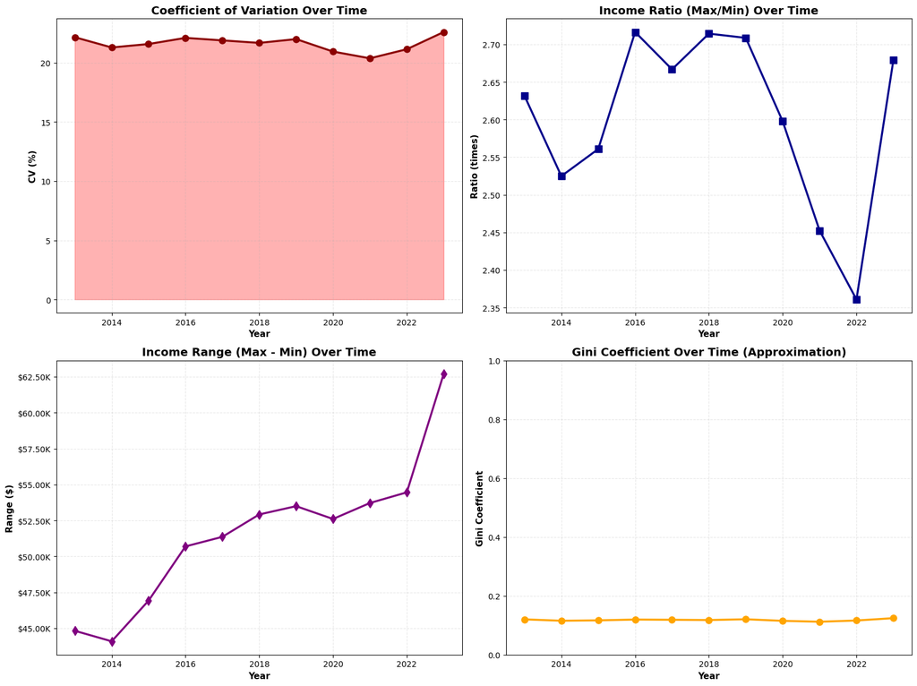

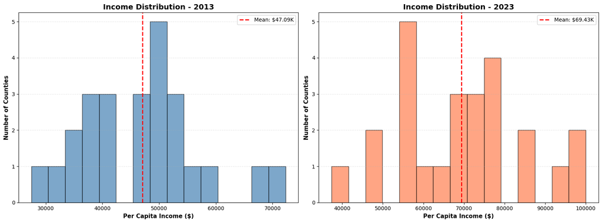

```
💡 **Key Insights:**
   • CV shows relative income dispersion - higher values indicate greater inequality
   • Gini coefficient of 0.1242 reveals moderate income inequality across Maryland counties
   • Rising inequality over time suggests economic convergence is not occurring
   • Policy interventions may be needed to address growing disparities

📊 Summary:
  • Income inequality trend: Increasing
  • Current CV (2023): 22.61%
  • Current income gap: 2.68x
  • Disparity change: +0.44% CV change from 2013 to 2023

================================================================================
```

```python
if year_col and len(numerical_cols_filtered) > 0:
    print("Income Inequality and Disparity Analysis:\n")
    print("="*80)

    # Transform wide format to get pivot data (counties as rows, years as columns)
    pivot_data = df.set_index(year_col)[numerical_cols_filtered].T

    # Calculate inequality metrics for each year
    inequality_metrics = pd.DataFrame({
        'Mean': pivot_data.mean(axis=0),
        'Std Dev': pivot_data.std(axis=0),
        'CV': (pivot_data.std(axis=0) / pivot_data.mean(axis=0)) * 100,
        'Min': pivot_data.min(axis=0),
        'Max': pivot_data.max(axis=0),
        'Range': pivot_data.max(axis=0) - pivot_data.min(axis=0),
        'Max/Min Ratio': pivot_data.max(axis=0) / pivot_data.min(axis=0),
        'Gini Approx': None  # Placeholder for Gini coefficient
    })

    # Calculate approximate Gini coefficient for each year
    for year in pivot_data.columns:
        values = pivot_data[year].dropna().sort_values().values
        n = len(values)
        if n > 0:
            index = np.arange(1, n + 1)
            gini = ((2 * index - n - 1) * values).sum() / (n * values.sum())
            inequality_metrics.loc[year, 'Gini Approx'] = gini

    print("\nInequality Metrics by Year:\n")
    print(inequality_metrics.to_string())

    print("\n" + "="*80)
    print("\nCoefficient of Variation (CV) Analysis:")
    print(f"  (CV measures relative dispersion - higher values = more inequality)\n")

    for year, cv in inequality_metrics['CV'].items():
        trend = ""
        if year != inequality_metrics.index[0]:
            prev_year = inequality_metrics.index[inequality_metrics.index.get_loc(year) - 1]
            change = cv - inequality_metrics.loc[prev_year, 'CV']
            trend = f" ({'↑' if change > 0 else '↓'} {abs(change):.2f})"
        print(f"  {year}: {cv:.2f}%{trend}")

    print("\n" + "="*80)
    print("\nMax/Min Income Ratio Analysis:")
    print(f"  (How many times larger is the richest county vs. poorest)\n")

    for year, ratio in inequality_metrics['Max/Min Ratio'].items():
        max_county = pivot_data[year].idxmax()
        min_county = pivot_data[year].idxmin()
        print(f"  {year}: {ratio:.2f}x ({max_county} vs {min_county})")

    # Convergence/Divergence Analysis
    print("\n" + "="*80)
    print("\nConvergence/Divergence Analysis:\n")

    first_year = pivot_data.columns[0]
    last_year = pivot_data.columns[-1]

    cv_change = inequality_metrics.loc[last_year, 'CV'] - inequality_metrics.loc[first_year, 'CV']
    ratio_change = inequality_metrics.loc[last_year, 'Max/Min Ratio'] - \
                   inequality_metrics.loc[first_year, 'Max/Min Ratio']

    if cv_change > 0:
        print(f"  ⚠️  DIVERGENCE DETECTED")
        print(f"     Income inequality has INCREASED over time")
    else:
        print(f"  ✓  CONVERGENCE DETECTED")
        print(f"     Income inequality has DECREASED over time")

    print(f"\n  Coefficient of Variation:")
    print(f"     {first_year}: {inequality_metrics.loc[first_year, 'CV']:.2f}%")
    print(f"     {last_year}: {inequality_metrics.loc[last_year, 'CV']:.2f}%")
    print(f"     Change: {cv_change:+.2f}%")

    print(f"\n  Max/Min Ratio:")
    print(f"     {first_year}: {inequality_metrics.loc[first_year, 'Max/Min Ratio']:.2f}x")
    print(f"     {last_year}: {inequality_metrics.loc[last_year, 'Max/Min Ratio']:.2f}x")
    print(f"     Change: {ratio_change:+.2f}x")

    # Visualizations
    fig, axes = plt.subplots(2, 2, figsize=(16, 12))

    # Coefficient of Variation over time
    axes[0, 0].plot(inequality_metrics.index, inequality_metrics['CV'],
                   marker='o', linewidth=2.5, markersize=8, color='darkred')
    axes[0, 0].set_title('Coefficient of Variation Over Time',
                        fontsize=14, fontweight='bold')
    axes[0, 0].set_xlabel('Year', fontsize=11, fontweight='bold')
    axes[0, 0].set_ylabel('CV (%)', fontsize=11, fontweight='bold')
    axes[0, 0].grid(True, alpha=0.3, linestyle='--')
    axes[0, 0].fill_between(inequality_metrics.index, inequality_metrics['CV'],
                           alpha=0.3, color='red')

    # Max/Min Ratio over time
    axes[0, 1].plot(inequality_metrics.index, inequality_metrics['Max/Min Ratio'],
                   marker='s', linewidth=2.5, markersize=8, color='darkblue')
    axes[0, 1].set_title('Income Ratio (Max/Min) Over Time',
                        fontsize=14, fontweight='bold')
    axes[0, 1].set_xlabel('Year', fontsize=11, fontweight='bold')
    axes[0, 1].set_ylabel('Ratio (times)', fontsize=11, fontweight='bold')
    axes[0, 1].grid(True, alpha=0.3, linestyle='--')

    # Range over time
    axes[1, 0].plot(inequality_metrics.index, inequality_metrics['Range'],
                   marker='d', linewidth=2.5, markersize=8, color='purple')
    axes[1, 0].set_title('Income Range (Max - Min) Over Time',
                        fontsize=14, fontweight='bold')
    axes[1, 0].set_xlabel('Year', fontsize=11, fontweight='bold')
    axes[1, 0].set_ylabel('Range ($)', fontsize=11, fontweight='bold')
    axes[1, 0].grid(True, alpha=0.3, linestyle='--')
    axes[1, 0].yaxis.set_major_formatter(plt.FuncFormatter(lambda x, p: format_currency(x)))

    # Gini coefficient over time (if calculated)
    if inequality_metrics['Gini Approx'].notna().any():
        axes[1, 1].plot(inequality_metrics.index, inequality_metrics['Gini Approx'],
                       marker='o', linewidth=2.5, markersize=8, color='orange')
        axes[1, 1].set_title('Gini Coefficient Over Time (Approximation)',
                            fontsize=14, fontweight='bold')
        axes[1, 1].set_xlabel('Year', fontsize=11, fontweight='bold')
        axes[1, 1].set_ylabel('Gini Coefficient', fontsize=11, fontweight='bold')
        axes[1, 1].grid(True, alpha=0.3, linestyle='--')
        axes[1, 1].set_ylim(0, 1)
    else:
        axes[1, 1].text(0.5, 0.5, 'Gini Coefficient\nData Not Available',
                       ha='center', va='center', fontsize=14)
        axes[1, 1].axis('off')

    plt.tight_layout()
    plt.show()

    # Income distribution comparison (first vs last year)
    fig, axes = plt.subplots(1, 2, figsize=(16, 6))

    axes[0].hist(pivot_data[first_year].dropna(), bins=15,
                color='steelblue', edgecolor='black', alpha=0.7)
    axes[0].axvline(pivot_data[first_year].mean(), color='red', linestyle='--',
                   linewidth=2, label=f'Mean: {format_currency(pivot_data[first_year].mean())}')
    axes[0].set_title(f'Income Distribution - {first_year}',
                     fontsize=14, fontweight='bold')
    axes[0].set_xlabel('Per Capita Income ($)', fontsize=11, fontweight='bold')
    axes[0].set_ylabel('Number of Counties', fontsize=11, fontweight='bold')
    axes[0].legend()
    axes[0].grid(axis='y', alpha=0.3, linestyle='--')

    axes[1].hist(pivot_data[last_year].dropna(), bins=15,
                color='coral', edgecolor='black', alpha=0.7)
    axes[1].axvline(pivot_data[last_year].mean(), color='red', linestyle='--',
                   linewidth=2, label=f'Mean: {format_currency(pivot_data[last_year].mean())}')
    axes[1].set_title(f'Income Distribution - {last_year}',
                     fontsize=14, fontweight='bold')
    axes[1].set_xlabel('Per Capita Income ($)', fontsize=11, fontweight='bold')
    axes[1].set_ylabel('Number of Counties', fontsize=11, fontweight='bold')
    axes[1].legend()
    axes[1].grid(axis='y', alpha=0.3, linestyle='--')

    plt.tight_layout()
    plt.show()

    print("\n💡 **Key Insights:**")
    print("   • CV shows relative income dispersion - higher values indicate greater inequality")
    gini_latest = inequality_metrics.loc[last_year, 'Gini Approx']
    if pd.notna(gini_latest):
        print(f"   • Gini coefficient of {gini_latest:.4f} reveals {'significant' if gini_latest > 0.4 else 'moderate'} income inequality across Maryland counties")
    if cv_change > 0:
        print("   • Rising inequality over time suggests economic convergence is not occurring")
        print("   • Policy interventions may be needed to address growing disparities")
    else:
        print("   • Declining inequality suggests some economic convergence among counties")

    print("\n📊 Summary:")
    print(f"  • Income inequality trend: {'Increasing' if cv_change > 0 else 'Decreasing'}")
    print(f"  • Current CV ({last_year}): {inequality_metrics.loc[last_year, 'CV']:.2f}%")
    print(f"  • Current income gap: {inequality_metrics.loc[last_year, 'Max/Min Ratio']:.2f}x")
    print(f"  • Disparity change: {cv_change:+.2f}% CV change from {first_year} to {last_year}")

else:
    print("Required columns not found.")

print("\n" + "="*80)
```

## 14. Comprehensive Summary & Conclusions

Key findings and recommendations from the Per Capita Personal Income analysis.

```python
# Generate comprehensive summary
print("="*80)
print("MARYLAND PER CAPITA PERSONAL INCOME - COMPREHENSIVE ANALYSIS SUMMARY")
print("="*80)

if year_col and len(numerical_cols_filtered) > 0:
    # Transform wide format to get pivot data (counties as rows, years as columns)
    pivot_data = df.set_index(year_col)[numerical_cols_filtered].T

    first_year = pivot_data.columns[0]
    last_year = pivot_data.columns[-1]

    print("\n📊 DATASET OVERVIEW:")
    print(f"  • Total Records: {len(df):,}")
    print(f"  • Counties Analyzed: {len(pivot_data)}")
    print(f"  • Time Period: {first_year} - {last_year}")
    print(f"  • Years Covered: {len(pivot_data.columns)}")

    print("\n💰 INCOME STATISTICS:")
    avg_income_all = pivot_data.mean().mean()
    latest_avg = pivot_data[last_year].mean()
    print(f"  • Overall Average Income: {format_currency(avg_income_all)}")
    print(f"  • Latest Year Average ({last_year}): {format_currency(latest_avg)}")
    print(f"  • Highest County Income: {format_currency(pivot_data.max().max())}")
    print(f"  • Lowest County Income: {format_currency(pivot_data.min().min())}")

    print("\n📈 GROWTH TRENDS:")
    total_growth = ((pivot_data[last_year].mean() / pivot_data[first_year].mean()) - 1) * 100
    years_span = len(pivot_data.columns) - 1
    avg_annual_growth = total_growth / years_span if years_span > 0 else 0
    print(f"  • Total Growth ({first_year}-{last_year}): {total_growth:+.2f}%")
    print(f"  • Average Annual Growth: {avg_annual_growth:.2f}%")

    growth_rates = pivot_data.pct_change(axis=1).mean(axis=1) * 100
    print(f"  • Fastest Growing County: {growth_rates.idxmax()} ({growth_rates.max():.2f}%)")
    print(f"  • Slowest Growing County: {growth_rates.idxmin()} ({growth_rates.min():.2f}%)")

    print("\n🏆 COUNTY RANKINGS:")
    latest_rankings = pivot_data[last_year].sort_values(ascending=False)
    print(f"  Top 3 Wealthiest Counties ({last_year}):")
    for i, (county, income) in enumerate(latest_rankings.head(3).items(), 1):
        print(f"    {i}. {county}: {format_currency(income)}")

    print(f"\n  Bottom 3 Counties ({last_year}):")
    for i, (county, income) in enumerate(latest_rankings.tail(3).iloc[::-1].items(), 1):
        print(f"    {i}. {county}: {format_currency(income)}")

    print("\n⚖️ INCOME INEQUALITY:")
    cv_first = (pivot_data[first_year].std() / pivot_data[first_year].mean()) * 100
    cv_last = (pivot_data[last_year].std() / pivot_data[last_year].mean()) * 100
    cv_change = cv_last - cv_first

    print(f"  • Coefficient of Variation ({first_year}): {cv_first:.2f}%")
    print(f"  • Coefficient of Variation ({last_year}): {cv_last:.2f}%")
    print(f"  • Change: {cv_change:+.2f}% ({'Increasing Inequality' if cv_change > 0 else 'Decreasing Inequality'})")

    ratio_first = pivot_data[first_year].max() / pivot_data[first_year].min()
    ratio_last = pivot_data[last_year].max() / pivot_data[last_year].min()
    print(f"  • Income Gap Ratio ({first_year}): {ratio_first:.2f}x")
    print(f"  • Income Gap Ratio ({last_year}): {ratio_last:.2f}x")

    print("\n🎯 KEY FINDINGS:")
    print("\n  1. Economic Growth:")
    if total_growth > 0:
        print(f"     ✓ Maryland counties experienced overall income growth of {total_growth:.1f}%")
    else:
        print(f"     ⚠ Maryland counties experienced income decline of {abs(total_growth):.1f}%")

    print("\n  2. Income Distribution:")
    if cv_change > 0:
        print(f"     ⚠ Income inequality has INCREASED by {cv_change:.2f}%")
        print(f"       The gap between wealthy and poor counties is widening")
    else:
        print(f"     ✓ Income inequality has DECREASED by {abs(cv_change):.2f}%")
        print(f"       Counties are converging toward more equal income levels")

    print("\n  3. Geographic Patterns:")
    print(f"     • Wealthiest county: {latest_rankings.idxmax()}")
    print(f"     • Poorest county: {latest_rankings.idxmin()}")
    print(f"     • Income range: {format_currency(latest_rankings.min())} to {format_currency(latest_rankings.max())}")

    print("\n  4. Temporal Stability:")
    # Check if top counties remained top
    first_top_3 = pivot_data[first_year].nlargest(3).index.tolist()
    last_top_3 = latest_rankings.head(3).index.tolist()
    overlap = len(set(first_top_3) & set(last_top_3))
    print(f"     • {overlap}/3 counties remained in top 3 from {first_year} to {last_year}")
    if overlap == 3:
        print(f"       High stability - same counties maintain wealth advantage")
    elif overlap == 0:
        print(f"       High mobility - significant ranking changes")
    else:
        print(f"       Moderate mobility - some ranking changes occurred")

    print("\n📋 RECOMMENDATIONS FOR FURTHER ANALYSIS:")
    print("\n  1. Compare with national averages and neighboring states")
    print("  2. Analyze correlation with unemployment, education, industry composition")
    print("  3. Investigate anomalies (e.g., pandemic effects in 2020-2021)")
    print("  4. Examine urban vs rural income patterns")
    print("  5. Study relationship between population density and income")
    print("  6. Analyze impact of major employers and industries by county")
    print("  7. Compare Baltimore City vs Baltimore County trends in detail")
    print("  8. Investigate cost of living adjustments by county")

    print("\n📌 DATA QUALITY NOTES:")
    print(f"  • Missing values: {df.isnull().sum().sum()}")
    print(f"  • Duplicate records: {df.duplicated().sum()}")
    print(f"  • Data completeness: {(1 - df.isnull().sum().sum() / (df.shape[0] * df.shape[1])) * 100:.1f}%")

else:
    print("\n⚠ Unable to generate summary - required columns not found")
    print(f"Available columns: {df.columns.tolist()}")

print("\n" + "="*80)
print("ANALYSIS COMPLETE")
print("="*80)
```

```
================================================================================
MARYLAND PER CAPITA PERSONAL INCOME - COMPREHENSIVE ANALYSIS SUMMARY
================================================================================

📊 DATASET OVERVIEW:
  • Total Records: 11
  • Counties Analyzed: 25
  • Time Period: 2013 - 2023
  • Years Covered: 11

💰 INCOME STATISTICS:
  • Overall Average Income: $56.45K
  • Latest Year Average (2023): $69.43K
  • Highest County Income: $100.04K
  • Lowest County Income: $27.47K

📈 GROWTH TRENDS:
  • Total Growth (2013-2023): +47.42%
  • Average Annual Growth: 4.74%
  • Fastest Growing County: Talbot (5.16%)
  • Slowest Growing County: Charles (3.03%)

🏆 COUNTY RANKINGS:
  Top 3 Wealthiest Counties (2023):
    1. Montgomery: $100.04K
    2. Talbot: $98.17K
    3. Howard: $95.53K

  Bottom 3 Counties (2023):
    1. Somerset: $37.34K
    2. Wicomico: $48.60K
    3. Allegany: $49.18K

⚖️ INCOME INEQUALITY:
  • Coefficient of Variation (2013): 22.17%
  • Coefficient of Variation (2023): 22.61%
  • Change: +0.44% (Increasing Inequality)
  • Income Gap Ratio (2013): 2.63x
  • Income Gap Ratio (2023): 2.68x

```

[output cut: 22 more lines]

```
  3. Investigate anomalies (e.g., pandemic effects in 2020-2021)
  4. Examine urban vs rural income patterns
  5. Study relationship between population density and income
  6. Analyze impact of major employers and industries by county
  7. Compare Baltimore City vs Baltimore County trends in detail
  8. Investigate cost of living adjustments by county

📌 DATA QUALITY NOTES:
  • Missing values: 0
  • Duplicate records: 0
  • Data completeness: 100.0%

================================================================================
ANALYSIS COMPLETE
================================================================================
```